# Predicting the Number of Bike Shares

In this analysis we would like to predict the count of bike rentals in Washington DC with a regression analysis, Decision Trees, Support Vector Machines (SVMs) and Neural Networks (NN).

# 0. Import Packages

Before the project starts, all required packages are imported.

```r
library(ggplot2)
library(e1071)
library(mgcv)
library(corrplot)
library(tree)
library(mgcv)
library(tidyverse)
library(boot)
library(MASS)
library(ipred)
library(randomForest)
library(gbm)
library(modelr)
library(neuralnet)
library(h2o)
library(bit64)
library(caret)
```

# 1. Getting Data

## Data source

We downloaded the dataset “bikesharing.csv” from https://code.datasciencedojo.com/datasciencedojo/datasets/tree/master/Bike%20Sharing.

## Loading the data

In a first step the dataset is imported to R and stored in the data.frame *d.bike*:

```r
d.bike <- read.csv("bikesharing.csv", header=TRUE)
```

## Describing the dataset

The dataset contains hourly information about a day and its weather conditions in 17379 observations of 17 variables. In the following, the individual attributes will be explained:

- *instant*: record index
- *dteday*: Date
- *season*: 1 = spring, 2 = summer, 3 = fall, 4 = winter
- *yr*: Year; 0: 2011, 1: 2012
- *mnth*: Month; 1 to 12
- *hr*: Hour; 0 to 23
- *holiday*: 0 = no holiday, 1 = holiday
- *weekday*: Day of the week; 1 to 7
- *workingday*: 0 = weekend or holiday, 1 = working day
- *weathersit*:
  - 1: Clear, Few clouds, Partly cloudy, Partly cloudy
  - 2: Mist + Cloudy, Mist + Broken clouds, Mist + Few clouds, Mist
  - 3: Light Snow, Light Rain + Thunderstorm + Scattered clouds, Light Rain + Scattered clouds
  - 4: Heavy Rain + Ice Pallets + Thunderstorm + Mist, Snow + Fog
- *temp*: Normalized temperature in Celsius; The values are derived via (t-t_min)/(t_max-t_min), t_min=-8, t_max=+39;
- *atemp*: Normalized feeling temperature in Celsius; Normalized feeling temperature in Celsius. The values are derived via (t-t_min)/(t_max-t_min), t_min=-16, t_max=+50
- *hum*: Normalized relative humidity; The values are divided to 100 (max);
- *windspeed*: Normalized windspeed ; The values are divided to 67 (max)
- *casual*: number of non-registered (eg. tourists)
- *registered*: number of registered users (eg. workers that use bikes daily)
- *cnt*: number of total rentals

## Investigating the correlation between all predictors

In order to make a valid feature selection in the next step, we now want to investigate the correlation between the predictors. The so-called corrplot offers a simple and clear display. This shows a correlation matrix. Correlations are represented by dots. The exact value can be read off the scale.

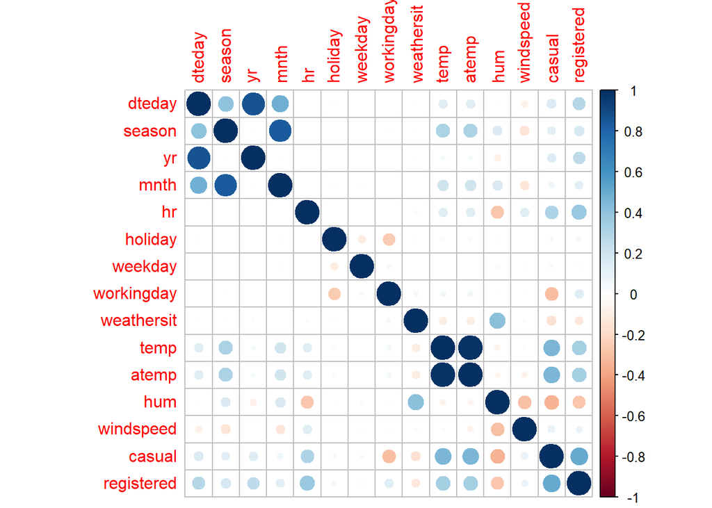

```r
predictors = c("dteday", "season", "yr","mnth","hr","holiday","weekday",
             "workingday","weathersit","temp","atemp","hum","windspeed", "casual", "registered")
corrplot(cor(data.matrix(d.bike[predictors])))
```

As the corrplot shows, dteday correlates strongly with the predictor yr. Furthermore it can be seen that there is a correlation between dteday and season as well as mnth. There is also a relatively strong correlation between month and season.The strongest correlation of almost 1 shows temp and atemp.

## Feature Selection

We decide to delete the feature *instant* and *dteday*. *instant* is a record index that has been artificially created. Therefore it will have no relevant effect on *cnt*. *dteday* is the date of the record. It correlates with the three other attributes *season*, *yr* and *mnth*. The features season and mnth as well as temp and atem will be kept for now.

```r
d.bike <- subset(d.bike, select=-c(instant, dteday))
```

## Checking the data

```r
head(d.bike)
```

```
##   season yr mnth hr holiday weekday workingday weathersit temp  atemp  hum
## 1      1  0    1  0       0       6          0          1 0.24 0.2879 0.81
## 2      1  0    1  1       0       6          0          1 0.22 0.2727 0.80
## 3      1  0    1  2       0       6          0          1 0.22 0.2727 0.80
## 4      1  0    1  3       0       6          0          1 0.24 0.2879 0.75
## 5      1  0    1  4       0       6          0          1 0.24 0.2879 0.75
## 6      1  0    1  5       0       6          0          2 0.24 0.2576 0.75
##   windspeed casual registered cnt
## 1    0.0000      3         13  16
## 2    0.0000      8         32  40
## 3    0.0000      5         27  32
## 4    0.0000      3         10  13
## 5    0.0000      0          1   1
## 6    0.0896      0          1   1
```

```r
tail(d.bike)
```

```
##       season yr mnth hr holiday weekday workingday weathersit temp  atemp  hum
## 17374      1  1   12 18       0       1          1          2 0.26 0.2727 0.48
## 17375      1  1   12 19       0       1          1          2 0.26 0.2576 0.60
## 17376      1  1   12 20       0       1          1          2 0.26 0.2576 0.60
## 17377      1  1   12 21       0       1          1          1 0.26 0.2576 0.60
## 17378      1  1   12 22       0       1          1          1 0.26 0.2727 0.56
## 17379      1  1   12 23       0       1          1          1 0.26 0.2727 0.65
##       windspeed casual registered cnt
## 17374    0.1343     10        112 122
## 17375    0.1642     11        108 119
## 17376    0.1642      8         81  89
## 17377    0.1642      7         83  90
## 17378    0.1343     13         48  61
## 17379    0.1343     12         37  49
```

As it looks like the data set was imported completely. To check if there are any missing values (not available, NA) in this dataset we count the number of NAs in the data set.

```r
sum(is.na(d.bike))
```

```
## [1] 0
```

```r
mean(is.na(d.bike))
```

```
## [1] 0
```

The record contains no rows with missing data.

## Creating training and test data set

At this point the data set d.bike is divided into training and test set. The training set should consist of 75% of the data and the test set of 25% of the data.

```r
d.bike.train.id <- sample(seq_len(nrow(d.bike)),size = floor(0.75*nrow(d.bike)))
d.bike.train <- d.bike[d.bike.train.id,]
d.bike.test <- d.bike[-d.bike.train.id,]
```

# 2. Explorative Data Analysis

In this section each attribute is considered to make certain assumptions. Different statistical diagrams are used for this purpose. The effects of the different attributes on cnt are tested using ANOVA for categorical attributes and a linear regression model for numerical values. The aim of this explorative data analysis is to get a starting point for the model building.

To keep our documentation clear, not all graphical analyses are shown. For example, interactions between predictors are not shown in this document but only described. At these points, references are made to the R-file.

## Count

In the very first step we would like to look at the distribution of the response variable count. For this purpose we create a histogram.

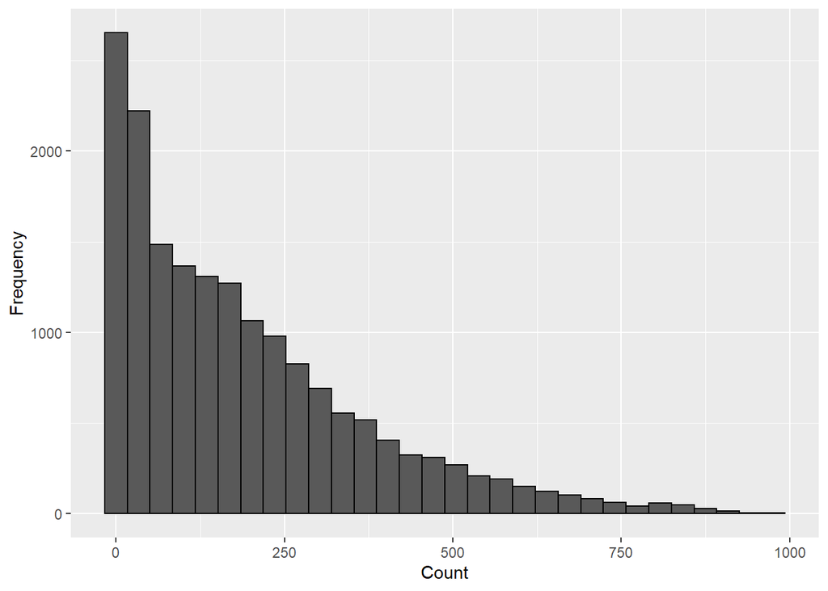

```r
ggplot(data = d.bike, aes(x=cnt)) +
  geom_histogram(bins=30, colour="black", ylab="Frequency") + xlab("Count") + ylab("Frequency")
```

```r
mean(d.bike$cnt)
```

```
## [1] 189.4631
```

```r
sd(d.bike$cnt)
```

```
## [1] 181.3876
```

As we can see, this is a right skewed gamma distribution. So in most hours - the number of bike rentals are hourly observations - between 0 and 30 bikes (the most left bar) are rented.

Bootstrapping:

```r
mean(d.bike$cnt)
```

```
## [1] 189.4631
```

```r
id <- sample(1:length(d.bike$cnt), replace = TRUE)
mean(d.bike$cnt[id])
```

```
## [1] 188.984
```

```r
B <- 1000
t.mean <- c()
for(i in 1:B){
  t.id <- sample(1:length(d.bike$cnt), replace = TRUE)
  t.d.bike <- d.bike$cnt[t.id]
  t.mean[i] <- mean(t.d.bike)
}
length(t.mean)
```

```
## [1] 1000
```

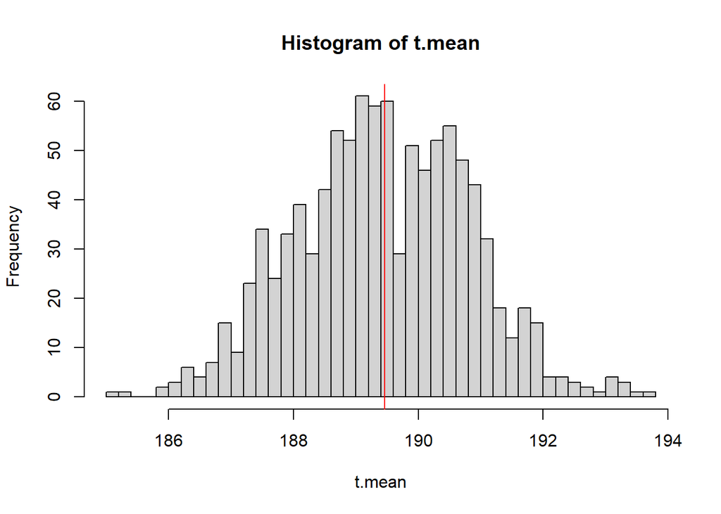

```r
hist(t.mean, breaks = 50)
abline(v = mean(d.bike$cnt), col = "red")
```

```r
sorted.means <- sort(t.mean)
quantile(sorted.means, probs = c(0.025, 0.975))
```

```
##     2.5%    97.5%
## 186.8310 191.9523
```

## Season

If we want to visualize the effect of the *season* as a categorical variable on the number of bike rentals it is a good idea to use a box plot.

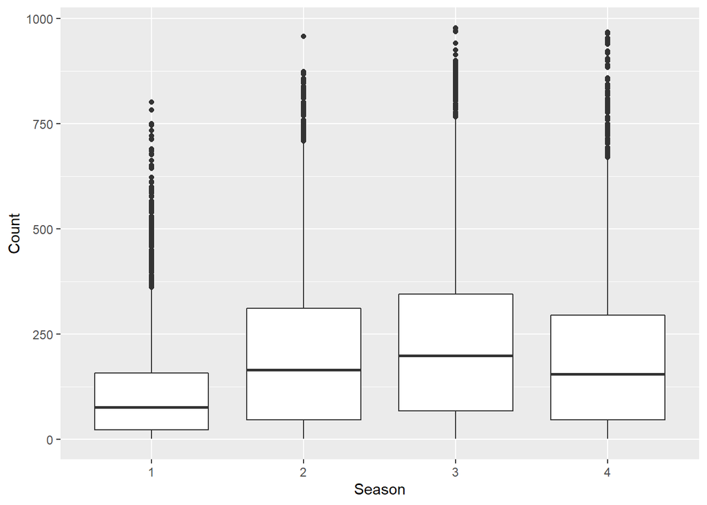

```r
ggplot(data = d.bike, aes(group=season, y = cnt, x = as.factor(season))) +
  geom_boxplot() + xlab("Season") + ylab("Count")
```

As the box plot shows, season 1 (spring) is particularly different from season 2, 3 and 4 (summer, autumn and winter). The median is lowest in spring, even lower than in winter. In summer, autumn and winter, the medians differ only marginally. Since the medians differ partially, one can assume a slight effect. However, we want to examine this more closely.

With an Analysis of Variance (ANOVA) we check whether at least one level of Seasons has a significant effect on the number of bike rentals. The first step is to create a model that does not consider any effect from *season*. With an F-test we compare then both models with each other.

```r
lm.season.1 <- lm(cnt ~ as.factor(season), data = d.bike)
lm.season.0 <- lm(cnt ~ 1, data = d.bike)
anova(lm.season.0, lm.season.1)
```

```
## Analysis of Variance Table
##
## Model 1: cnt ~ 1
## Model 2: cnt ~ as.factor(season)
##   Res.Df       RSS Df Sum of Sq      F    Pr(>F)
## 1  17378 571761591
## 2  17375 534032233  3  37729358 409.18 < 2.2e-16 ***
## ---
## Signif. codes:  0 '***' 0.001 '**' 0.01 '*' 0.05 '.' 0.1 ' ' 1
```

As we can see from the p-value there is strong evidence that at least one level in *season* has a strong effect on the number of bike rentals. The lower value of the residual sums of squares in lm.season.1 also indicates that the more complex model has smaller residuals than the less complex model lm.season.0.

## Year

Since we also consider year to be a categorical variable, a box plot is again a good choice. For all categorical variables we will use a boxplot for the graphical representation in the following.

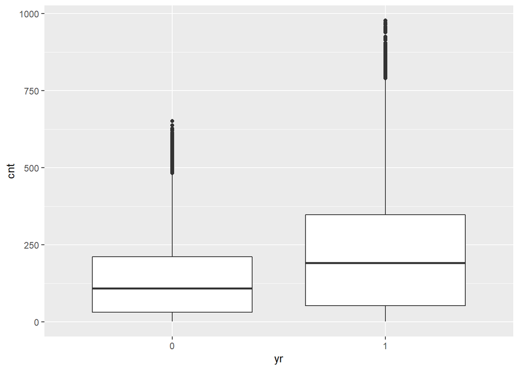

```r
ggplot(data = d.bike, aes(group=yr, y = cnt, x = yr)) +
  geom_boxplot()
```

At first glance we can see that the number of bike rentals has increased in year 1 (2012). The median is above the median of year 0 (2011).

```r
lm.year.1 <- lm(cnt ~ as.factor(yr), data = d.bike)
lm.year.0 <- lm(cnt ~ 1, data = d.bike)
anova(lm.year.0, lm.year.1)
```

```
## Analysis of Variance Table
##
## Model 1: cnt ~ 1
## Model 2: cnt ~ as.factor(yr)
##   Res.Df       RSS Df Sum of Sq      F    Pr(>F)
## 1  17378 571761591
## 2  17377 535884870  1  35876722 1163.4 < 2.2e-16 ***
## ---
## Signif. codes:  0 '***' 0.001 '**' 0.01 '*' 0.05 '.' 0.1 ' ' 1
```

## Month

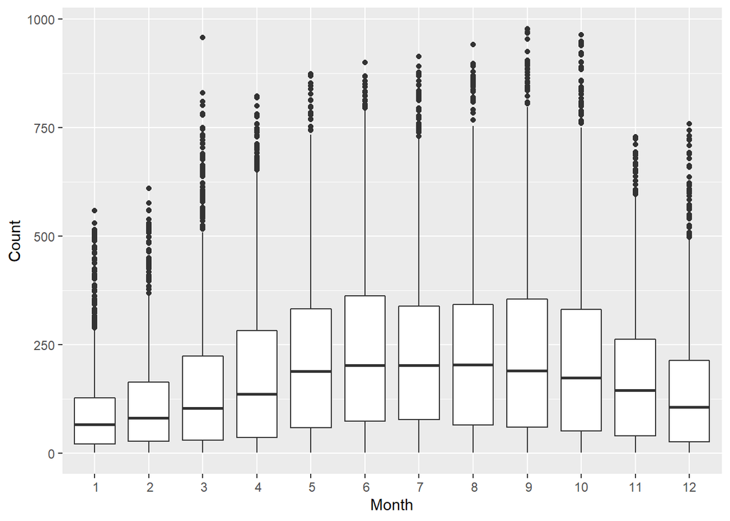

```r
ggplot(data = d.bike, aes(group=mnth, y = cnt, x = as.factor(mnth))) +
  geom_boxplot() + scale_x_discrete(limits=seq(1,12)) + xlab("Month") + ylab("Count")
```

Here we see that the bike rental increased during the summer months May to September or when the temperatures were more pleasant. Visually, the months seem to have an effect on cnt.

```r
lm.month.1 <- lm(cnt ~ as.factor(mnth), data = d.bike)
lm.month.0 <- lm(cnt ~ 1, data = d.bike)
anova(lm.month.0, lm.month.1)
```

```
## Analysis of Variance Table
##
## Model 1: cnt ~ 1
## Model 2: cnt ~ as.factor(mnth)
##   Res.Df       RSS Df Sum of Sq     F    Pr(>F)
## 1  17378 571761591
## 2  17367 528851615 11  42909976 128.1 < 2.2e-16 ***
## ---
## Signif. codes:  0 '***' 0.001 '**' 0.01 '*' 0.05 '.' 0.1 ' ' 1
```

As the p-value shows, there is strong evidence that at least one month must have a significant effect on cnt. Also the RSS shows little surprising. The more complex model lm.month.1 seems to represent the data better than the model lm.month.0.

## Hour

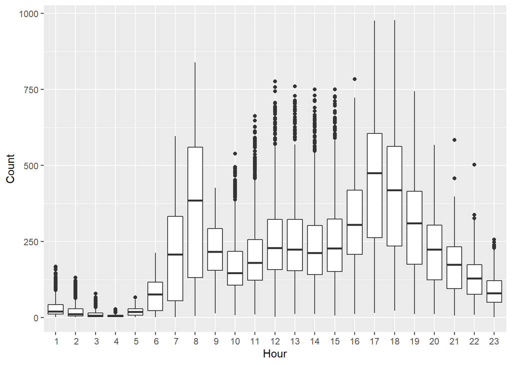

```r
ggplot(data = d.bike, aes(group=hr, y = cnt, x = as.factor(hr))) +
  geom_boxplot() + scale_x_discrete(limits=seq(1,23)) + xlab("Hour") + ylab("Count")
```

The same applies to the time of day and hour. Bikes were most often rented in the morning between 7 and 8 am. and in the evening between 5 and 6 pm. The same flow also applies to the median. The individual times of day seem to differ greatly from one another.

```r
lm.hr.1 <- lm(cnt ~ as.factor(hr), data = d.bike)
lm.hr.0 <- lm(cnt ~ 1, data = d.bike)
anova(lm.hr.0, lm.hr.1)
```

```
## Analysis of Variance Table
##
## Model 1: cnt ~ 1
## Model 2: cnt ~ as.factor(hr)
##   Res.Df       RSS Df Sum of Sq      F    Pr(>F)
## 1  17378 571761591
## 2  17355 285026910 23 286734681 759.09 < 2.2e-16 ***
## ---
## Signif. codes:  0 '***' 0.001 '**' 0.01 '*' 0.05 '.' 0.1 ' ' 1
```

The p-value also reflects this. At least one time of day has a significant effect on cnt. The RSS differs here extremely strongly between complex and simple models. The time of day will probably play a role in the final regression model.

## Holiday

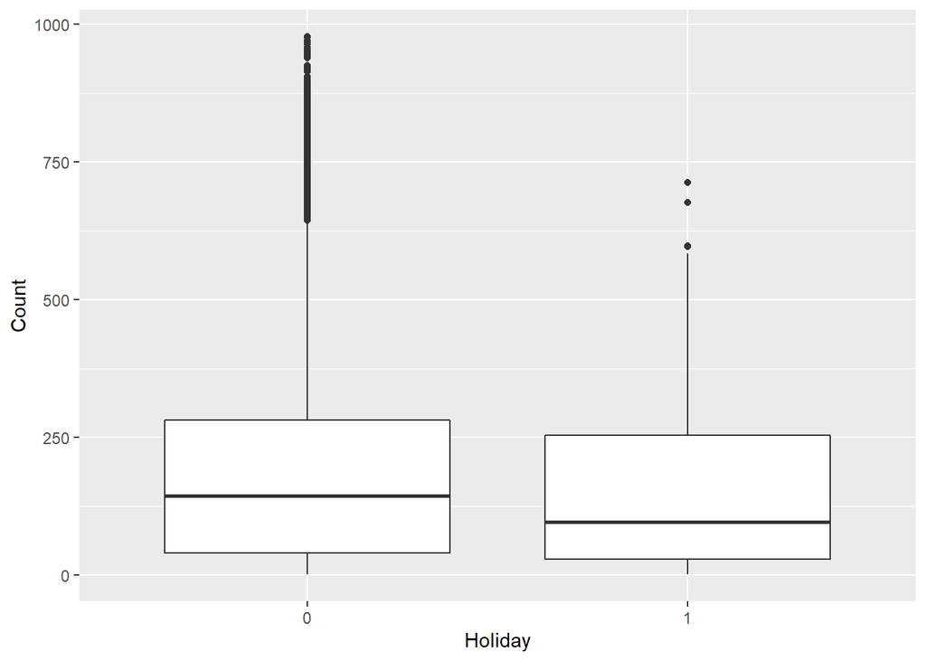

```r
ggplot(data = d.bike, aes(group=holiday, y = cnt, x = as.factor(holiday))) +
  geom_boxplot() + xlab("Holiday") + ylab("Count")
```

During the holiday period, fewer bikes are rented according to the boxplot diagram. However, the difference is very pleasant compared to the normal working period. The holiday period median is close to the work time median.

```r
lm.holiday.1 <- lm(cnt ~ as.factor(holiday), data = d.bike)
lm.holiday.0 <- lm(cnt ~ 1, data = d.bike)
anova(lm.holiday.0, lm.holiday.1)
```

```
## Analysis of Variance Table
##
## Model 1: cnt ~ 1
## Model 2: cnt ~ as.factor(holiday)
##   Res.Df       RSS Df Sum of Sq      F    Pr(>F)
## 1  17378 571761591
## 2  17377 571214702  1    546889 16.637 4.546e-05 ***
## ---
## Signif. codes:  0 '***' 0.001 '**' 0.01 '*' 0.05 '.' 0.1 ' ' 1
```

The p-value shows strong evidence that no holiday and/or holiday has a significant effect on cnt. However, if we look at RSS at this point, which differs only minimally between simple and complex model, holiday could be a feature that will be not included in the model.

## Weekday

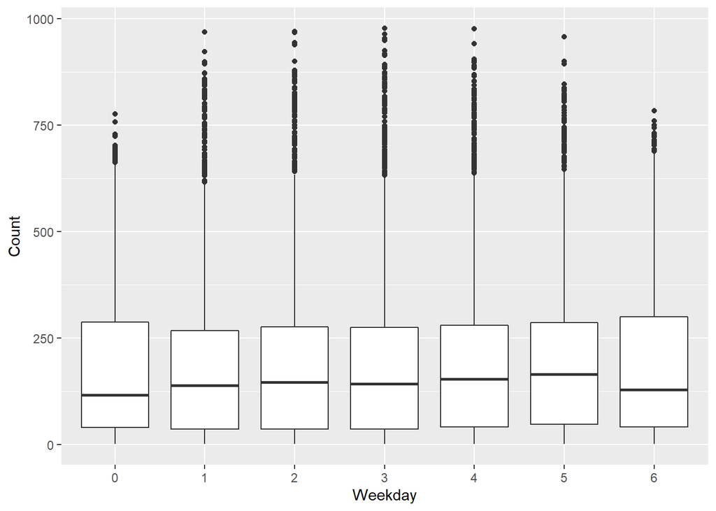

```r
ggplot(data = d.bike, aes(group=weekday, y= cnt, x = as.factor(weekday))) +
  geom_boxplot() + xlab("Weekday") + ylab("Count")
```

```r
lm.weekday.1 <- lm(cnt ~ as.factor(weekday), data = d.bike)
lm.weekday.0 <- lm(cnt ~ 1, data = d.bike)
anova(lm.weekday.0, lm.weekday.1)
```

```
## Analysis of Variance Table
##
## Model 1: cnt ~ 1
## Model 2: cnt ~ as.factor(weekday)
##   Res.Df       RSS Df Sum of Sq      F   Pr(>F)
## 1  17378 571761591
## 2  17372 571073662  6    687929 3.4878 0.001899 **
## ---
## Signif. codes:  0 '***' 0.001 '**' 0.01 '*' 0.05 '.' 0.1 ' ' 1
```

As the p-value shows, there is only medium evidence that at least one weekday has a significant effect on cnt. Also the RSS does not differ too much between simple and complex model. This leads to the conclusion that probably the weekday is not included in the final model.

## Working day

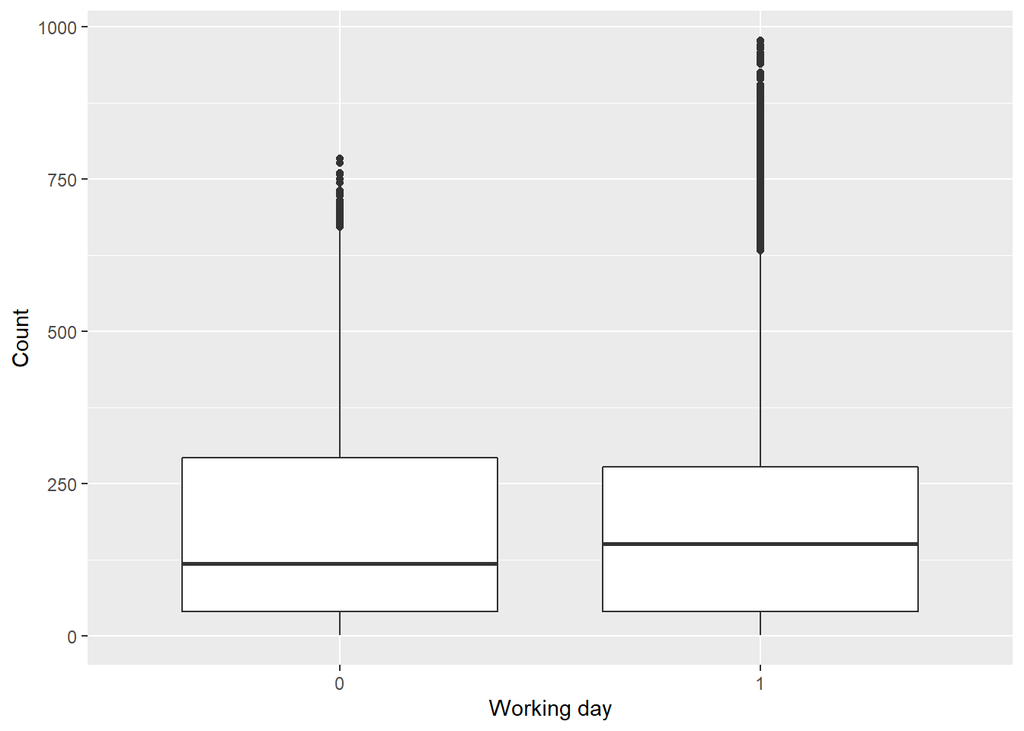

```r
ggplot(data = d.bike, aes(group=workingday, y = cnt, x = as.factor(workingday))) +
  geom_boxplot() + xlab("Working day") + ylab("Count")
```

On working or not-working days, the count of the bike rentals are almost equal. This is also identical with the both medians.

```r
lm.workingday.1 <- lm(cnt ~ as.factor(workingday), data = d.bike)
lm.workingday.0 <- lm(cnt ~ 1, data = d.bike)
anova(lm.workingday.0, lm.workingday.1)
```

```
## Analysis of Variance Table
##
## Model 1: cnt ~ 1
## Model 2: cnt ~ as.factor(workingday)
##   Res.Df       RSS Df Sum of Sq      F    Pr(>F)
## 1  17378 571761591
## 2  17377 571237204  1    524387 15.952 6.524e-05 ***
## ---
## Signif. codes:  0 '***' 0.001 '**' 0.01 '*' 0.05 '.' 0.1 ' ' 1
```

As the p-value shows, there is strong evidence that the no working day and/or working day has a significant effect on cnt. Again, the RSS does not differ very much. Working day possibly brings no benefit in the model and will probably be omitted.

## Weather Situation

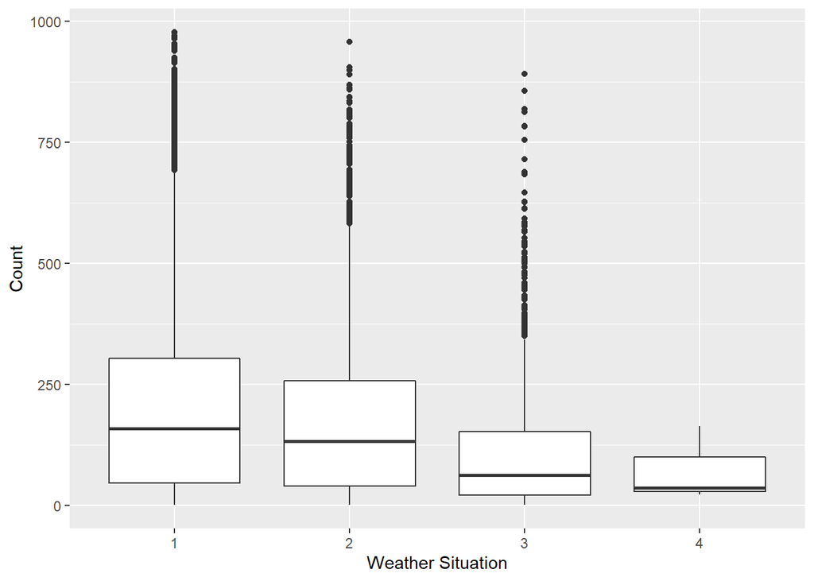

```r
ggplot(data = d.bike, aes(group=weathersit, y = cnt, x = as.factor(weathersit))) +
  geom_boxplot()  + xlab("Weather Situation") + ylab("Count")
```

If we look at the weather divided on a scale between 1 and 4 as shown in the boxplot, we see that the bike rental is steadily decreasing from 1 to 4. The value 1 is the good weather and 4 the bad weather. Whereby from the value 3 away, probably already bad weather, the renting goes down faster. An identical flow can also be observed for the medians, starting from the first box plot 1 to 4.

```r
lm.weathersit.1 <- lm(cnt ~ as.factor(weathersit), data = d.bike)
lm.weathersit.0 <- lm(cnt ~ 1, data = d.bike)
anova(lm.weathersit.0, lm.weathersit.1)
```

```
## Analysis of Variance Table
##
## Model 1: cnt ~ 1
## Model 2: cnt ~ as.factor(weathersit)
##   Res.Df       RSS Df Sum of Sq      F    Pr(>F)
## 1  17378 571761591
## 2  17375 559476561  3  12285030 127.17 < 2.2e-16 ***
## ---
## Signif. codes:  0 '***' 0.001 '**' 0.01 '*' 0.05 '.' 0.1 ' ' 1
```

## Temperature

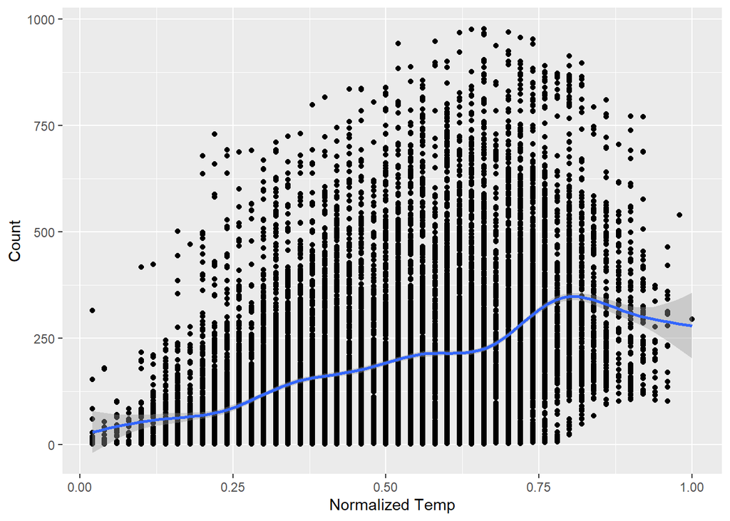

```r
ggplot(data = d.bike, mapping = aes(y = cnt, x = temp)) +
  geom_point()  + xlab("Normalized Temp") + ylab("Count") + geom_smooth()
```

The representation of the regression line confirms the positive correlation. As the smoothing spline shows, temperature is a more complex relationship than linearity. It is possible that a Generalised Additive Model (GAM) could be used if temp is considered in the final model. As it seems higher temperatures lead to a higher number of rented bikes.

```r
library(mgcv)
gam.temp.1 <- gam(cnt ~ s(temp), data = d.bike)
summary(gam.temp.1)
```

```
##
## Family: gaussian
## Link function: identity
##
## Formula:
## cnt ~ s(temp)
##
## Parametric coefficients:
##             Estimate Std. Error t value Pr(>|t|)
## (Intercept)  189.463      1.252   151.3   <2e-16 ***
## ---
## Signif. codes:  0 '***' 0.001 '**' 0.01 '*' 0.05 '.' 0.1 ' ' 1
##
## Approximate significance of smooth terms:
##           edf Ref.df     F p-value
## s(temp) 8.747  8.975 403.3  <2e-16 ***
## ---
## Signif. codes:  0 '***' 0.001 '**' 0.01 '*' 0.05 '.' 0.1 ' ' 1
##
## R-sq.(adj) =  0.172   Deviance explained = 17.3%
## GCV =  27250  Scale est. = 27235     n = 17379
```

First, a relatively high estimated degree of freedom (edf) of 8,747 is striking. This indicates the high complexity of the relationship. The p-value shows strong evidence that the slope is not 0 and thus there is a correlation between temp and cnt. The adjusted R-Squared shows that 17 percent of the variability is explained by the data. Thus temp could play a role in the final model. temp shows interaction effects with all of the categorical variables except the yr (see line 142, group13_bikesharing.R).

## Feeling Temperature

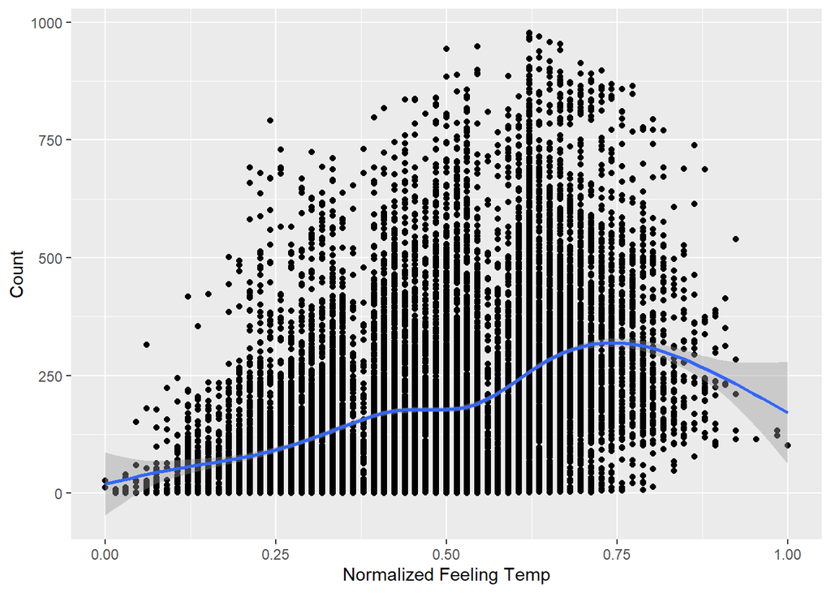

```r
ggplot(data = d.bike, mapping = aes(y = cnt, x = atemp)) +
  geom_point() + xlab("Normalized Feeling Temp") + ylab("Count") + geom_smooth()
```

Not surprisingly, atemp is also related to a higher degree of complexity. So again a GAM is useful to investigate the effect of atemp on cnt.

```r
gam.atemp.1 <- gam(cnt ~ s(atemp), data = d.bike)
summary(gam.atemp.1)
```

```
##
## Family: gaussian
## Link function: identity
##
## Formula:
## cnt ~ s(atemp)
##
## Parametric coefficients:
##             Estimate Std. Error t value Pr(>|t|)
## (Intercept)  189.463      1.253   151.2   <2e-16 ***
## ---
## Signif. codes:  0 '***' 0.001 '**' 0.01 '*' 0.05 '.' 0.1 ' ' 1
##
## Approximate significance of smooth terms:
##            edf Ref.df     F p-value
## s(atemp) 7.556  8.338 427.3  <2e-16 ***
## ---
## Signif. codes:  0 '***' 0.001 '**' 0.01 '*' 0.05 '.' 0.1 ' ' 1
##
## R-sq.(adj) =   0.17   Deviance explained = 17.1%
## GCV =  27315  Scale est. = 27301     n = 17379
```

The edf again shows a more complex relationship between atemp and cnt. The p-value shows strong evidence that the slope is not 0. The R-Squared shows that the model explains 17% of the data. Therefore, atemp could also play a role in the final model. atemp shows interaction effects with all of the categorical variables except the yr (see line 160, group13_bikesharing.R).

## Humidity

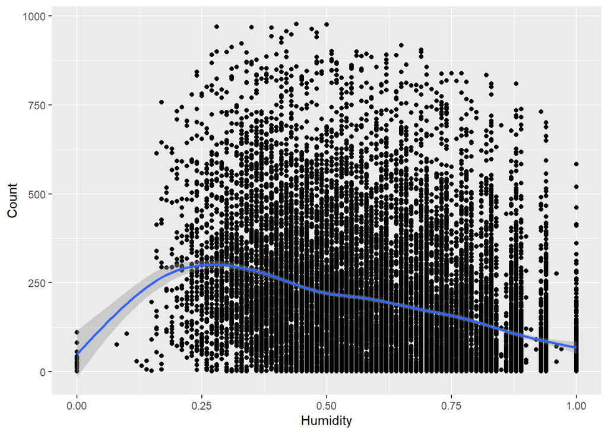

```r
ggplot(data = d.bike, mapping = aes(y = cnt, x = hum)) +
  geom_point() + xlab("Humidity") + ylab("Count") + geom_smooth()
```

The smoothing spline shows a possible quadratic effect of hum on cnt. Once again, a GAM is the obvious choice.

```r
gam.hum.1 <- gam(cnt ~ s(hum), data = d.bike)
summary(gam.hum.1)
```

```
##
## Family: gaussian
## Link function: identity
##
## Formula:
## cnt ~ s(hum)
##
## Parametric coefficients:
##             Estimate Std. Error t value Pr(>|t|)
## (Intercept)  189.463      1.298     146   <2e-16 ***
## ---
## Signif. codes:  0 '***' 0.001 '**' 0.01 '*' 0.05 '.' 0.1 ' ' 1
##
## Approximate significance of smooth terms:
##          edf Ref.df     F p-value
## s(hum) 7.872  8.548 252.8  <2e-16 ***
## ---
## Signif. codes:  0 '***' 0.001 '**' 0.01 '*' 0.05 '.' 0.1 ' ' 1
##
## R-sq.(adj) =  0.111   Deviance explained = 11.1%
## GCV =  29281  Scale est. = 29266     n = 17379
```

As the hypothesis test shows, there is strong evidence that hum has an effect on cnt. Furthermore, the R-Squared shows that the model explains 11% of the data. Thus, hum could also be relevant for the final model. hum shows interaction effects with all of the categorical variables (see line 178, group13_bikesharing.R).

## Windspeed

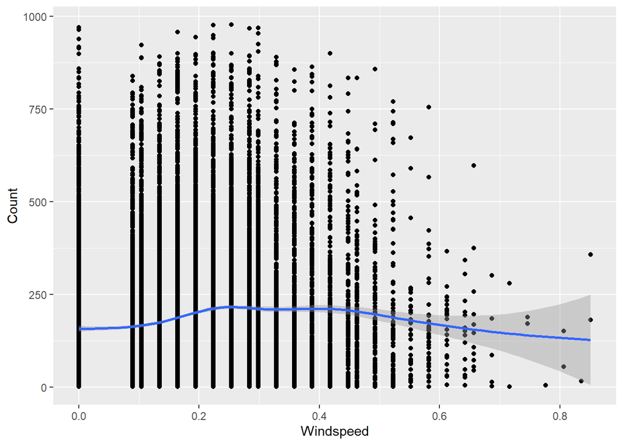

```r
ggplot(data = d.bike, mapping = aes(y = cnt, x = windspeed)) +
  geom_point() + xlab("Windspeed") + ylab("Count") + geom_smooth()
```

The graph shows that windspeed might have a linear effect on cnt. Furthermore the smoothing spline shows that there is very little influence of windspeed, because the curve is almost flat.

```r
lm.windspeed.1 <- lm(cnt ~ windspeed, data = d.bike)
summary(lm.windspeed.1)
```

```
##
## Call:
## lm(formula = cnt ~ windspeed, data = d.bike)
##
## Residuals:
##     Min      1Q  Median      3Q     Max
## -265.47 -146.00  -48.75   90.25  806.81
##
## Coefficients:
##             Estimate Std. Error t value Pr(>|t|)
## (Intercept)  163.185      2.532   64.46   <2e-16 ***
## windspeed    138.233     11.198   12.34   <2e-16 ***
## ---
## Signif. codes:  0 '***' 0.001 '**' 0.01 '*' 0.05 '.' 0.1 ' ' 1
##
## Residual standard error: 180.6 on 17377 degrees of freedom
## Multiple R-squared:  0.008693,   Adjusted R-squared:  0.008635
## F-statistic: 152.4 on 1 and 17377 DF,  p-value: < 2.2e-16
```

The wind speed has a positive effect on cnt. This is surprising, since the observed data seems to decrease with increasing wind speed. As R-Squared shows, this regression model explains only 0.8% of the data. This indicates that the attribute can be omitted in the final model.

## Casual Users and registered users

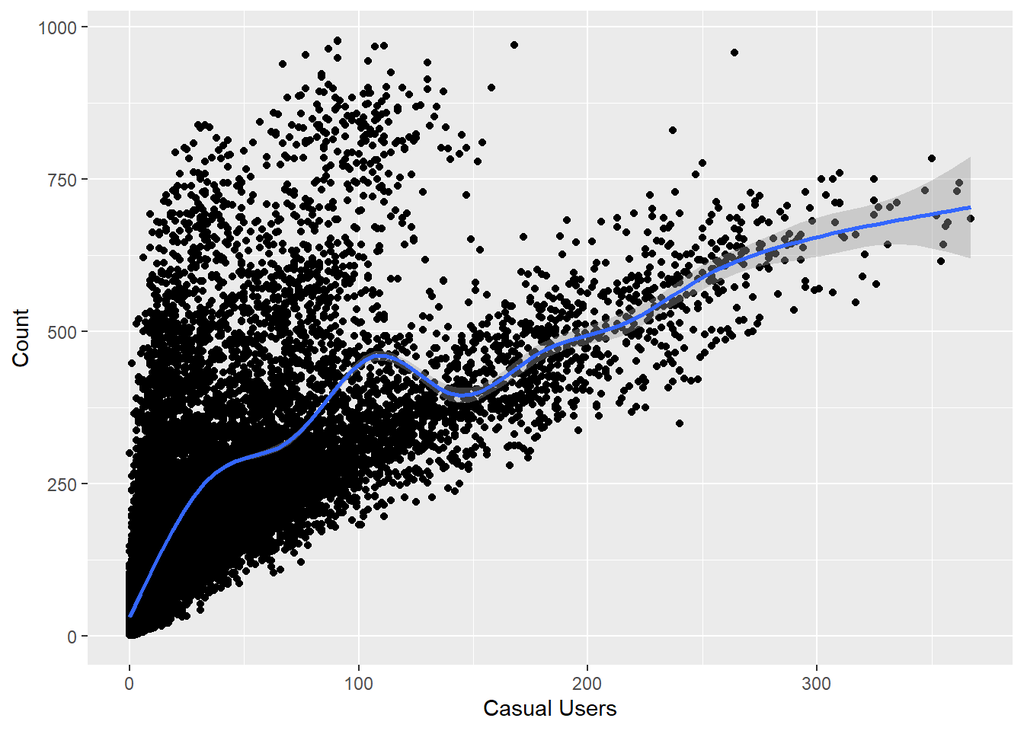

```r
ggplot(data = d.bike, mapping = aes(y = cnt, x = casual)) +
  geom_point() + xlab("Casual Users") + ylab("Count") + geom_smooth()
```

```r
gam.casual.1 <- gam(cnt ~ s(casual), data = d.bike)
summary(gam.casual.1)
```

```
##
## Family: gaussian
## Link function: identity
##
## Formula:
## cnt ~ s(casual)
##
## Parametric coefficients:
##             Estimate Std. Error t value Pr(>|t|)
## (Intercept) 189.4631     0.8841   214.3   <2e-16 ***
## ---
## Signif. codes:  0 '***' 0.001 '**' 0.01 '*' 0.05 '.' 0.1 ' ' 1
##
## Approximate significance of smooth terms:
##             edf Ref.df    F p-value
## s(casual) 8.928  8.998 2748  <2e-16 ***
## ---
## Signif. codes:  0 '***' 0.001 '**' 0.01 '*' 0.05 '.' 0.1 ' ' 1
##
## R-sq.(adj) =  0.587   Deviance explained = 58.7%
## GCV =  13591  Scale est. = 13583     n = 17379
```

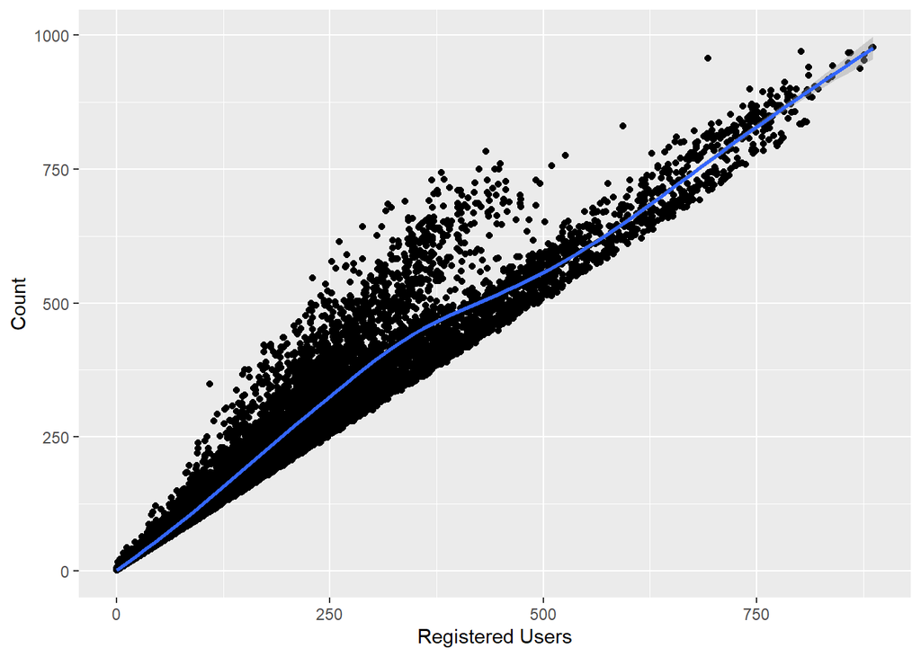

```r
ggplot(data = d.bike, mapping = aes(y = cnt, x = registered)) +
  geom_point() + xlab("Registered Users") + ylab("Count") + geom_smooth()
```

```r
lm.registered.1 <- lm(cnt ~ registered, data = d.bike)
summary(lm.registered.1)
```

```
##
## Call:
## lm(formula = cnt ~ registered, data = d.bike)
##
## Residuals:
##      Min       1Q   Median       3Q      Max
## -118.031  -16.264   -9.957    4.730  304.223
##
## Coefficients:
##              Estimate Std. Error t value Pr(>|t|)
## (Intercept) 10.296458   0.459718    22.4   <2e-16 ***
## registered   1.165032   0.002131   546.8   <2e-16 ***
## ---
## Signif. codes:  0 '***' 0.001 '**' 0.01 '*' 0.05 '.' 0.1 ' ' 1
##
## Residual standard error: 42.51 on 17377 degrees of freedom
## Multiple R-squared:  0.9451, Adjusted R-squared:  0.9451
## F-statistic: 2.99e+05 on 1 and 17377 DF,  p-value: < 2.2e-16
```

Both casual and registered users show a positive effect and explain a large part of the data with the model. This suggests that casual and registered users need not be considered separately. Furthermore, casual and registered users are not further distinguished and are therefore not considered in the model.

## Model development

In this section, the insights gained from the exploratory data analysis and the consideration of the individual attributes should help to form a hypothesis about what the final model might look like. This hypothesis is the starting point for developing the model.

The explorative data analysis has shown that the attributes season, yr, mnth, hr, weathersit, temp, atemp and hum can probably be considered in the model. From this, the following model can be assumed:

```
cnt = season + yr + mnth + hr + weathersit + temp + atemp + hum + season:temp + season:atemp + season:hum + yr:hum + mnth:temp + mnth:atemp + mnth:hum + hr:temp + hr:atemp + hr:hum + weathersit:temp + weathersit:atemp + weathersit:hum
```

First five models are initialized. The full model with all predictors, the starting model with all interactions, the starting model without considering the interactions, the starting model without considering the polynomial effect and the starting model without considering polynomial and interaction effects.

```r
full.model.1 <- cnt ~ as.factor(season) + as.factor(yr) + as.factor(mnth) + as.factor(hr) + as.factor(holiday) + as.factor(weekday) + as.factor(workingday) + as.factor(weathersit) + temp + atemp + hum + windspeed + casual + registered

starting.model.1 <- cnt ~ as.factor(season) + as.factor(yr) + as.factor(mnth) + as.factor(hr) + as.factor(weathersit) + poly(hum, degree = 8.7) + poly(temp, degree = 8) + poly(atemp, degree = 8.9) + season:temp + season:atemp + season:hum + yr:hum + mnth:temp + mnth:atemp + mnth:hum + hr:temp + hr:atemp + hr:hum + weathersit:temp + weathersit:atemp + weathersit:hum

starting.model.2 <- cnt ~ as.factor(season) + as.factor(yr) + as.factor(mnth) + as.factor(hr) + as.factor(weathersit) + poly(hum, degree = 8.7) + poly(temp, degree = 8) + poly(atemp, degree = 8.9)

starting.model.3 <- cnt ~ as.factor(season) + as.factor(yr) + as.factor(mnth) + as.factor(hr) + as.factor(weathersit) + temp + atemp + hum + season:temp + season:atemp + season:hum + yr:hum + mnth:temp + mnth:atemp + mnth:hum + hr:temp + hr:atemp + hr:hum + weathersit:temp + weathersit:atemp + weathersit:hum

starting.model.4 <- cnt ~ as.factor(season) + as.factor(yr) + as.factor(mnth) + as.factor(hr) + as.factor(weathersit) + temp + atemp + hum
```

To find out which of the four starting models fits the data better, the results of the four models are first compared.

```r
lm.starting.model.1 <- lm(starting.model.1, data = d.bike)
lm.starting.model.2 <- lm(starting.model.2, data = d.bike)
lm.starting.model.3 <- lm(starting.model.3, data = d.bike)
lm.starting.model.4 <- lm(starting.model.4, data = d.bike)
summary(lm.starting.model.1)$adj.r.squared
```

```
## [1] 0.7467235
```

```r
summary(lm.starting.model.2)$adj.r.squared
```

```
## [1] 0.6943448
```

```r
summary(lm.starting.model.3)$adj.r.squared
```

```
## [1] 0.7414885
```

```r
summary(lm.starting.model.4)$adj.r.squared
```

```
## [1] 0.6837583
```

If only the adjusted R-Squared is considered at this point, it is shown that the starting.model.1 with a value of about 0.747 explains the variability of the data better than the other starting models. Thus we take the starting.model.1 as a starting point for the model development.

```r
summary(lm.starting.model.1)
```

```
##
## Call:
## lm(formula = starting.model.1, data = d.bike)
##
## Residuals:
##     Min      1Q  Median      3Q     Max
## -409.85  -50.61   -3.05   41.55  431.06
##
## Coefficients: (4 not defined because of singularities)
##                              Estimate Std. Error t value Pr(>|t|)
## (Intercept)                -1.504e+02  2.732e+01  -5.505 3.74e-08 ***
## as.factor(season)2          4.552e+01  2.008e+01   2.267 0.023428 *
## as.factor(season)3          1.696e+02  4.735e+01   3.581 0.000343 ***
## as.factor(season)4          1.593e+02  2.250e+01   7.080 1.50e-12 ***
## as.factor(yr)1              1.729e+02  5.050e+00  34.232  < 2e-16 ***
## as.factor(mnth)2            1.749e+01  1.574e+01   1.111 0.266646
## as.factor(mnth)3           -2.784e+01  1.830e+01  -1.521 0.128260
## as.factor(mnth)4           -1.754e+00  3.004e+01  -0.058 0.953434
## as.factor(mnth)5            4.633e+01  3.951e+01   1.173 0.240950
## as.factor(mnth)6            5.654e+01  4.732e+01   1.195 0.232197
## as.factor(mnth)7           -1.583e+01  7.914e+01  -0.200 0.841505
## as.factor(mnth)8           -9.061e+01  6.983e+01  -1.298 0.194425
## as.factor(mnth)9           -3.648e+01  5.214e+01  -0.700 0.484183
## as.factor(mnth)10          -5.008e+01  3.398e+01  -1.474 0.140532
## as.factor(mnth)11          -1.219e+02  2.957e+01  -4.123 3.76e-05 ***
## as.factor(mnth)12          -8.407e+01  2.251e+01  -3.735 0.000188 ***
## as.factor(hr)1             -5.915e+00  2.355e+01  -0.251 0.801717
## as.factor(hr)2             -2.188e+01  2.367e+01  -0.924 0.355258
## as.factor(hr)3             -3.934e+01  2.450e+01  -1.606 0.108363
## as.factor(hr)4             -5.036e+01  2.494e+01  -2.019 0.043481 *
## as.factor(hr)5             -3.047e+01  2.457e+01  -1.240 0.214877
## as.factor(hr)6             -8.563e+00  2.427e+01  -0.353 0.724207
## as.factor(hr)7              5.986e+01  2.434e+01   2.459 0.013928 *
## as.factor(hr)8              2.063e+02  2.401e+01   8.593  < 2e-16 ***
## as.factor(hr)9              1.239e+02  2.338e+01   5.297 1.19e-07 ***
## as.factor(hr)10             8.564e+01  2.309e+01   3.708 0.000209 ***
## as.factor(hr)11             1.038e+02  2.287e+01   4.539 5.69e-06 ***
## as.factor(hr)12             1.458e+02  2.285e+01   6.379 1.83e-10 ***
## as.factor(hr)13             1.507e+02  2.295e+01   6.570 5.19e-11 ***
## as.factor(hr)14             1.421e+02  2.304e+01   6.170 6.98e-10 ***
```

[output cut: 151 more lines]

```
## temp:weathersit2            2.035e+00  6.183e+01   0.033 0.973736
## temp:weathersit3            2.983e+01  1.033e+02   0.289 0.772719
## temp:weathersit4           -4.949e+02  2.870e+03  -0.172 0.863102
## atemp:weathersit2          -2.220e+01  6.882e+01  -0.323 0.746973
## atemp:weathersit3          -8.854e+01  1.149e+02  -0.770 0.441079
## atemp:weathersit4           8.651e+02  2.579e+03   0.335 0.737282
## hum:weathersit2             3.037e+01  1.055e+01   2.879 0.003989 **
## hum:weathersit3            -3.694e+01  2.308e+01  -1.600 0.109568
## hum:weathersit4                    NA         NA      NA       NA
## ---
## Signif. codes:  0 '***' 0.001 '**' 0.01 '*' 0.05 '.' 0.1 ' ' 1
##
## Residual standard error: 91.29 on 17193 degrees of freedom
## Multiple R-squared:  0.7494, Adjusted R-squared:  0.7467
## F-statistic: 277.9 on 185 and 17193 DF,  p-value: < 2.2e-16
```

```r
##1. iteration
lm.starting.model.1 <- update(lm.starting.model.1, . ~ . - weathersit:atemp)
lm.starting.model.1 <- update(lm.starting.model.1, . ~ . - weathersit:temp)
lm.starting.model.1 <- update(lm.starting.model.1, . ~ . - hr:atemp)
lm.starting.model.1 <- update(lm.starting.model.1, . ~ . - mnth:temp)
##2. iteration
lm.starting.model.1 <- update(lm.starting.model.1, . ~ . - mnth:hum)
lm.starting.model.1 <- update(lm.starting.model.1, . ~ . - season:temp)
lm.starting.model.1 <- update(lm.starting.model.1, . ~ . - weathersit:hum)
summary(lm.starting.model.1)
```

```
##
## Call:
## lm(formula = cnt ~ as.factor(season) + as.factor(yr) + as.factor(mnth) +
##     as.factor(hr) + as.factor(weathersit) + poly(hum, degree = 8.7) +
##     poly(temp, degree = 8) + poly(atemp, degree = 8.9) + season:atemp +
##     season:hum + hum:yr + atemp:mnth + temp:hr + hum:hr, data = d.bike)
##
## Residuals:
##     Min      1Q  Median      3Q     Max
## -418.83  -51.19   -2.54   41.54  431.19
##
## Coefficients: (3 not defined because of singularities)
##                             Estimate Std. Error t value Pr(>|t|)
## (Intercept)                 -143.267     25.714  -5.572 2.56e-08 ***
## as.factor(season)2            73.324     17.205   4.262 2.04e-05 ***
## as.factor(season)3           298.104     38.588   7.725 1.18e-14 ***
## as.factor(season)4           195.091     16.508  11.818  < 2e-16 ***
## as.factor(yr)1               172.268      4.990  34.521  < 2e-16 ***
## as.factor(mnth)2              10.876     10.721   1.014 0.310367
## as.factor(mnth)3             -20.106     13.838  -1.453 0.146264
## as.factor(mnth)4              -9.261     23.624  -0.392 0.695051
## as.factor(mnth)5              21.410     30.430   0.704 0.481711
## as.factor(mnth)6               7.077     38.071   0.186 0.852537
## as.factor(mnth)7             -40.325     50.737  -0.795 0.426750
## as.factor(mnth)8            -113.138     47.319  -2.391 0.016815 *
## as.factor(mnth)9            -182.423     40.325  -4.524 6.11e-06 ***
## as.factor(mnth)10           -136.993     23.215  -5.901 3.68e-09 ***
## as.factor(mnth)11           -124.801     20.972  -5.951 2.72e-09 ***
## as.factor(mnth)12            -99.478     15.568  -6.390 1.70e-10 ***
## as.factor(hr)1                -7.430     22.747  -0.327 0.743961
## as.factor(hr)2               -20.040     22.900  -0.875 0.381518
## as.factor(hr)3               -37.708     23.616  -1.597 0.110357
## as.factor(hr)4               -51.305     24.012  -2.137 0.032644 *
## as.factor(hr)5               -32.269     23.650  -1.364 0.172442
## as.factor(hr)6                -7.857     23.362  -0.336 0.736631
## as.factor(hr)7                73.630     23.393   3.148 0.001649 **
## as.factor(hr)8               215.553     23.377   9.221  < 2e-16 ***
## as.factor(hr)9               130.726     22.817   5.729 1.02e-08 ***
## as.factor(hr)10               94.937     22.567   4.207 2.60e-05 ***
## as.factor(hr)11              112.811     22.286   5.062 4.19e-07 ***
```

[output cut: 97 more lines]

```
## hum:hr15                    -182.570     28.561  -6.392 1.68e-10 ***
## hum:hr16                    -201.586     28.365  -7.107 1.23e-12 ***
## hum:hr17                    -254.651     28.105  -9.061  < 2e-16 ***
## hum:hr18                    -215.800     28.146  -7.667 1.85e-14 ***
## hum:hr19                    -174.028     28.186  -6.174 6.80e-10 ***
## hum:hr20                    -111.621     28.358  -3.936 8.31e-05 ***
## hum:hr21                     -72.597     28.724  -2.527 0.011500 *
## hum:hr22                     -41.303     28.889  -1.430 0.152820
## hum:hr23                      -9.223     29.302  -0.315 0.752947
## ---
## Signif. codes:  0 '***' 0.001 '**' 0.01 '*' 0.05 '.' 0.1 ' ' 1
##
## Residual standard error: 91.56 on 17249 degrees of freedom
## Multiple R-squared:  0.7471, Adjusted R-squared:  0.7452
## F-statistic:   395 on 129 and 17249 DF,  p-value: < 2.2e-16
```

```
cnt = season + yr + mnth + hr + weathersit + temp + atemp + hum + season:atemp + season:hum + yr:hum + mnth:atemp + hr:temp + hr:hum
```

The predictors temp, atemp and hum show polynomial effects.

## Cross Validation

```r
lm.starting.model.1 <- lm(starting.model.1, data = d.bike)
lm.starting.model.2 <- lm(starting.model.2, data = d.bike)
lm.starting.model.3 <- lm(starting.model.3, data = d.bike)
lm.starting.model.4 <- lm(starting.model.4, data = d.bike)
lm.full.model.1 <- lm(full.model.1, data = d.bike)
lm.final.model.1 <- lm(final.model.1, data = d.bike)

for(i in 1:10){
  d.bike.train.id <- sample(seq_len(nrow(d.bike)),size = floor(0.75*nrow(d.bike)))
  d.bike.train <- d.bike[d.bike.train.id,]
  d.bike.test <- d.bike[-d.bike.train.id,]

  #predict data with starting model 1
  lm.starting.model.1.train <- lm(starting.model.1, data = d.bike.train)
  predicted.starting.model.1.test <- predict(lm.starting.model.1.train,
                                             newdata = d.bike.test)
  r.squared.starting.model.1 <- cor(predicted.starting.model.1.test, d.bike.test$cnt)^2

  #predict data with starting model 2
  lm.starting.model.2.train <- lm(starting.model.2, data = d.bike.train)
  predicted.starting.model.2.test <- predict(lm.starting.model.2.train,
                                             newdata = d.bike.test)
  r.squared.starting.model.2 <- cor(predicted.starting.model.2.test, d.bike.test$cnt)^2

  #predict data with starting model 3
  lm.starting.model.3.train <- lm(starting.model.3, data = d.bike.train)
  predicted.starting.model.3.test <- predict(lm.starting.model.3.train,
                                             newdata = d.bike.test)
  r.squared.starting.model.3 <- cor(predicted.starting.model.3.test, d.bike.test$cnt)^2

  #predict data with starting model 4
  lm.starting.model.4.train <- lm(starting.model.4, data = d.bike.train)
  predicted.starting.model.4.test <- predict(lm.starting.model.4.train,
                                             newdata = d.bike.test)
  r.squared.starting.model.4 <- cor(predicted.starting.model.4.test, d.bike.test$cnt)^2

  #predict data with full model
  lm.full.model.train <- lm(full.model.1, data = d.bike.train)
  predicted.full.model.test <- predict(lm.full.model.train,
                                       newdata = d.bike.test)
  r.squared.full.model <- cor(predicted.full.model.test, d.bike.test$cnt)^2

  #predict data with final model
  lm.final.model.train <- lm(final.model.1, data = d.bike.train)
  predicted.final.model.test <- predict(lm.final.model.train,
                                        newdata = d.bike.test)
  r.squared.final.model <- cor(predicted.final.model.test, d.bike.test$cnt)^2
}

mean(r.squared.starting.model.1)
```

```
## [1] 0.7542875
```

```r
mean(r.squared.starting.model.2)
```

```
## [1] 0.7072345
```

```r
mean(r.squared.starting.model.3)
```

```
## [1] 0.7492328
```

```r
mean(r.squared.starting.model.4)
```

```
## [1] 0.6984628
```

```r
mean(r.squared.full.model)
```

```
## [1] 1
```

```r
mean(r.squared.final.model)
```

```
## [1] 0.7535116
```

# 3. Regression Analysis

In this chapter the bike rental cnt will be predicted respectively estimated using a linear, a non-linear and a poisson regressive model. The three models will then be compared using a 10-fold cross-validation based on the R-Squared.

## Linear Regression

```r
lm.bike.1 <- lm(final.model.1, data = d.bike)
summary(lm.bike.1)
```

```
##
## Call:
## lm(formula = final.model.1, data = d.bike)
##
## Residuals:
##     Min      1Q  Median      3Q     Max
## -418.83  -51.19   -2.54   41.54  431.19
##
## Coefficients: (3 not defined because of singularities)
##                             Estimate Std. Error t value Pr(>|t|)
## (Intercept)                 -143.267     25.714  -5.572 2.56e-08 ***
## as.factor(season)2            73.324     17.205   4.262 2.04e-05 ***
## as.factor(season)3           298.104     38.588   7.725 1.18e-14 ***
## as.factor(season)4           195.091     16.508  11.818  < 2e-16 ***
## as.factor(yr)1               172.268      4.990  34.521  < 2e-16 ***
## as.factor(mnth)2              10.876     10.721   1.014 0.310367
## as.factor(mnth)3             -20.106     13.838  -1.453 0.146264
## as.factor(mnth)4              -9.261     23.624  -0.392 0.695051
## as.factor(mnth)5              21.410     30.430   0.704 0.481711
## as.factor(mnth)6               7.077     38.071   0.186 0.852537
## as.factor(mnth)7             -40.325     50.737  -0.795 0.426750
## as.factor(mnth)8            -113.138     47.319  -2.391 0.016815 *
## as.factor(mnth)9            -182.423     40.325  -4.524 6.11e-06 ***
## as.factor(mnth)10           -136.993     23.215  -5.901 3.68e-09 ***
## as.factor(mnth)11           -124.801     20.972  -5.951 2.72e-09 ***
## as.factor(mnth)12            -99.478     15.568  -6.390 1.70e-10 ***
## as.factor(hr)1                -7.430     22.747  -0.327 0.743961
## as.factor(hr)2               -20.040     22.900  -0.875 0.381518
## as.factor(hr)3               -37.708     23.616  -1.597 0.110357
## as.factor(hr)4               -51.305     24.012  -2.137 0.032644 *
## as.factor(hr)5               -32.269     23.650  -1.364 0.172442
## as.factor(hr)6                -7.857     23.362  -0.336 0.736631
## as.factor(hr)7                73.630     23.393   3.148 0.001649 **
## as.factor(hr)8               215.553     23.377   9.221  < 2e-16 ***
## as.factor(hr)9               130.726     22.817   5.729 1.02e-08 ***
## as.factor(hr)10               94.937     22.567   4.207 2.60e-05 ***
## as.factor(hr)11              112.811     22.286   5.062 4.19e-07 ***
## as.factor(hr)12              154.479     22.217   6.953 3.70e-12 ***
## as.factor(hr)13              159.391     22.255   7.162 8.27e-13 ***
## as.factor(hr)14              149.476     22.303   6.702 2.12e-11 ***
```

[output cut: 94 more lines]

```
## hum:hr15                    -182.570     28.561  -6.392 1.68e-10 ***
## hum:hr16                    -201.586     28.365  -7.107 1.23e-12 ***
## hum:hr17                    -254.651     28.105  -9.061  < 2e-16 ***
## hum:hr18                    -215.800     28.146  -7.667 1.85e-14 ***
## hum:hr19                    -174.028     28.186  -6.174 6.80e-10 ***
## hum:hr20                    -111.621     28.358  -3.936 8.31e-05 ***
## hum:hr21                     -72.597     28.724  -2.527 0.011500 *
## hum:hr22                     -41.303     28.889  -1.430 0.152820
## hum:hr23                      -9.223     29.302  -0.315 0.752947
## ---
## Signif. codes:  0 '***' 0.001 '**' 0.01 '*' 0.05 '.' 0.1 ' ' 1
##
## Residual standard error: 91.56 on 17249 degrees of freedom
## Multiple R-squared:  0.7471, Adjusted R-squared:  0.7452
## F-statistic:   395 on 129 and 17249 DF,  p-value: < 2.2e-16
```

The linear regression model explains about 74.5 of the variability of the data. This value has already been calculated in the section “Model development”.

## Non-linear Regression

```r
gam.bike.1 <- gam(cnt ~ as.factor(season) + as.factor(yr) + as.factor(mnth) + as.factor(hr) + as.factor(weathersit) + s(hum) + s(temp) + s(atemp) + atemp:season + hum:season + hum:yr + atemp:mnth + temp:hr + hum:hr, data = d.bike)
summary(gam.bike.1)
```

```
##
## Family: gaussian
## Link function: identity
##
## Formula:
## cnt ~ as.factor(season) + as.factor(yr) + as.factor(mnth) + as.factor(hr) +
##     as.factor(weathersit) + s(hum) + s(temp) + s(atemp) + atemp:season +
##     hum:season + hum:yr + atemp:mnth + temp:hr + hum:hr
##
## Parametric coefficients:
##                        Estimate Std. Error t value Pr(>|t|)
## (Intercept)             -43.398     16.243  -2.672 0.007553 **
## as.factor(season)2       74.999     17.194   4.362 1.30e-05 ***
## as.factor(season)3      293.571     38.505   7.624 2.58e-14 ***
## as.factor(season)4      195.233     16.481  11.846  < 2e-16 ***
## as.factor(yr)1          171.915      4.985  34.488  < 2e-16 ***
## as.factor(mnth)2         11.712     10.671   1.098 0.272415
## as.factor(mnth)3        -20.249     13.820  -1.465 0.142874
## as.factor(mnth)4        -10.974     23.573  -0.466 0.641566
## as.factor(mnth)5         19.163     30.338   0.632 0.527623
## as.factor(mnth)6          9.738     37.840   0.257 0.796904
## as.factor(mnth)7        -46.450     50.499  -0.920 0.357685
## as.factor(mnth)8       -117.640     47.115  -2.497 0.012539 *
## as.factor(mnth)9       -183.342     40.241  -4.556 5.25e-06 ***
## as.factor(mnth)10      -139.991     23.235  -6.025 1.72e-09 ***
## as.factor(mnth)11      -123.205     20.955  -5.880 4.19e-09 ***
## as.factor(mnth)12       -97.427     15.571  -6.257 4.02e-10 ***
## as.factor(hr)1           -7.863     22.719  -0.346 0.729288
## as.factor(hr)2          -20.528     22.883  -0.897 0.369683
## as.factor(hr)3          -37.976     23.592  -1.610 0.107486
## as.factor(hr)4          -51.447     23.989  -2.145 0.031995 *
## as.factor(hr)5          -32.069     23.623  -1.358 0.174623
## as.factor(hr)6           -8.429     23.330  -0.361 0.717871
## as.factor(hr)7           73.174     23.363   3.132 0.001739 **
## as.factor(hr)8          214.416     23.350   9.183  < 2e-16 ***
## as.factor(hr)9          130.314     22.802   5.715 1.12e-08 ***
## as.factor(hr)10          94.999     22.551   4.213 2.54e-05 ***
## as.factor(hr)11         111.927     22.270   5.026 5.06e-07 ***
## as.factor(hr)12         153.188     22.199   6.901 5.36e-12 ***
## as.factor(hr)13         157.793     22.238   7.096 1.34e-12 ***
```

[output cut: 79 more lines]

```
## hum:hr23                 -9.072     29.285  -0.310 0.756722
## ---
## Signif. codes:  0 '***' 0.001 '**' 0.01 '*' 0.05 '.' 0.1 ' ' 1
##
## Approximate significance of smooth terms:
##            edf Ref.df      F p-value
## s(hum)   8.801  8.973 10.864  <2e-16 ***
## s(temp)  6.954  7.939 16.889  <2e-16 ***
## s(atemp) 5.788  6.908  1.734  0.0933 .
## ---
## Signif. codes:  0 '***' 0.001 '**' 0.01 '*' 0.05 '.' 0.1 ' ' 1
##
## Rank: 133/136
## R-sq.(adj) =  0.745   Deviance explained = 74.7%
## GCV = 8437.1  Scale est. = 8375.2    n = 17379
```

The non-linear regression model shows the same result as the linear regression model. The variability of the data is explained by 74.5%.

```r
poi.bike.1 <- glm(final.model.1, data = d.bike)
summary(poi.bike.1)
```

```
##
## Call:
## glm(formula = final.model.1, data = d.bike)
##
## Deviance Residuals:
##     Min       1Q   Median       3Q      Max
## -418.83   -51.19    -2.54    41.54   431.19
##
## Coefficients: (3 not defined because of singularities)
##                             Estimate Std. Error t value Pr(>|t|)
## (Intercept)                 -143.267     25.714  -5.572 2.56e-08 ***
## as.factor(season)2            73.324     17.205   4.262 2.04e-05 ***
## as.factor(season)3           298.104     38.588   7.725 1.18e-14 ***
## as.factor(season)4           195.091     16.508  11.818  < 2e-16 ***
## as.factor(yr)1               172.268      4.990  34.521  < 2e-16 ***
## as.factor(mnth)2              10.876     10.721   1.014 0.310367
## as.factor(mnth)3             -20.106     13.838  -1.453 0.146264
## as.factor(mnth)4              -9.261     23.624  -0.392 0.695051
## as.factor(mnth)5              21.410     30.430   0.704 0.481711
## as.factor(mnth)6               7.077     38.071   0.186 0.852537
## as.factor(mnth)7             -40.325     50.737  -0.795 0.426750
## as.factor(mnth)8            -113.138     47.319  -2.391 0.016815 *
## as.factor(mnth)9            -182.423     40.325  -4.524 6.11e-06 ***
## as.factor(mnth)10           -136.993     23.215  -5.901 3.68e-09 ***
## as.factor(mnth)11           -124.801     20.972  -5.951 2.72e-09 ***
## as.factor(mnth)12            -99.478     15.568  -6.390 1.70e-10 ***
## as.factor(hr)1                -7.430     22.747  -0.327 0.743961
## as.factor(hr)2               -20.040     22.900  -0.875 0.381518
## as.factor(hr)3               -37.708     23.616  -1.597 0.110357
## as.factor(hr)4               -51.305     24.012  -2.137 0.032644 *
## as.factor(hr)5               -32.269     23.650  -1.364 0.172442
## as.factor(hr)6                -7.857     23.362  -0.336 0.736631
## as.factor(hr)7                73.630     23.393   3.148 0.001649 **
## as.factor(hr)8               215.553     23.377   9.221  < 2e-16 ***
## as.factor(hr)9               130.726     22.817   5.729 1.02e-08 ***
## as.factor(hr)10               94.937     22.567   4.207 2.60e-05 ***
## as.factor(hr)11              112.811     22.286   5.062 4.19e-07 ***
## as.factor(hr)12              154.479     22.217   6.953 3.70e-12 ***
## as.factor(hr)13              159.391     22.255   7.162 8.27e-13 ***
## as.factor(hr)14              149.476     22.303   6.702 2.12e-11 ***
```

[output cut: 98 more lines]

```
## hum:hr19                    -174.028     28.186  -6.174 6.80e-10 ***
## hum:hr20                    -111.621     28.358  -3.936 8.31e-05 ***
## hum:hr21                     -72.597     28.724  -2.527 0.011500 *
## hum:hr22                     -41.303     28.889  -1.430 0.152820
## hum:hr23                      -9.223     29.302  -0.315 0.752947
## ---
## Signif. codes:  0 '***' 0.001 '**' 0.01 '*' 0.05 '.' 0.1 ' ' 1
##
## (Dispersion parameter for gaussian family taken to be 8383.607)
##
##     Null deviance: 571761591  on 17378  degrees of freedom
## Residual deviance: 144608842  on 17249  degrees of freedom
## AIC: 206453
##
## Number of Fisher Scoring iterations: 2
```

## Comparing the models

To enable a meaningful comparison between the three models, the models should train 10 times with the training set and then predict the new data. Finally, the corresponding R-Squared of all three models is compared to each other to make a statement about the best model.

```r
for(i in 1:10){
  d.bike.train.id <- sample(seq_len(nrow(d.bike)),size = floor(0.75*nrow(d.bike)))
  d.bike.train <- d.bike[d.bike.train.id,]
  d.bike.test <- d.bike[-d.bike.train.id,]

  #predict data with linear model
  lm.bike.1.train <- lm(final.model.1, data = d.bike.train)
  predicted.lm.bike.1.test <- predict(lm.bike.1.train,
                                             newdata = d.bike.test)
  r.squared.lm.bike.1 <- cor(predicted.lm.bike.1.test, d.bike.test$cnt)^2

  #predict data with non-linear model
  gam.bike.1.train <- gam(cnt ~ as.factor(season) + as.factor(yr) + as.factor(mnth) + as.factor(hr) + as.factor(weathersit) + s(hum) + s(temp) + s(atemp) + atemp:season + hum:season + hum:yr + atemp:mnth + temp:hr + hum:hr, data = d.bike.train)
  predicted.gam.bike.1.test <- predict(gam.bike.1.train,
                                        newdata = d.bike.test)
  r.squared.gam.bike.1 <- cor(predicted.gam.bike.1.test, d.bike.test$cnt)^2

  #predict data with poisson model
  poi.bike.1.train <- glm(final.model.1, data = d.bike)
  predicted.poi.bike.1.test <- predict(poi.bike.1.train,
                                        newdata = d.bike.test)
  r.squared.poi.bike.1 <- cor(predicted.poi.bike.1.test, d.bike.test$cnt)^2
}

mean(r.squared.lm.bike.1)
```

```
## [1] 0.7286108
```

```r
mean(r.squared.gam.bike.1)
```

```
## [1] 0.728941
```

```r
mean(r.squared.poi.bike.1)
```

```
## [1] 0.7328381
```

# 4. Trees

In this chapter a classification tree and a regression tree are used to predict cnt. Once as class and once as discrete value. Afterwards, the regression tree model is used to analyse the bagging, random forests and boosting procedures.

## Classification Tree

```r
max(d.bike.new$cnt)
```

```
## [1] 977
```

```r
max(d.bike.new$cnt)/5
```

```
## [1] 195.4
```

```r
for(i in 1:nrow(d.bike)){
  if(d.bike.new$cnt[i] >= 0 & d.bike.new$cnt[i] < 196){
    d.bike.new$class[i] <- 0
  } else if (d.bike.new$cnt[i] >= 196 & d.bike.new$cnt[i] < 391){
    d.bike.new$class[i] <- 1
  } else if (d.bike.new$cnt[i] >= 391 & d.bike.new$cnt[i] < 586){
    d.bike.new$class[i] <- 2
  } else if (d.bike.new$cnt[i] >= 586 & d.bike.new$cnt[i] < 781){
    d.bike.new$class[i] <- 3
  } else if (d.bike.new$cnt[i] >= 781 & d.bike.new$cnt[i] <= 977){
    d.bike.new$class[i] <- 4
  }
}

d.bike.train.id <- sample(seq_len(nrow(d.bike.new)),size = floor(0.75*nrow(d.bike.new)))
d.bike.train.new <- d.bike.new[d.bike.train.id,]
d.bike.test.new <- d.bike.new[-d.bike.train.id,]
```

On the basis of the five defined classes, a classification tree is now fitted on the training data set. That it is a classification tree is shown by the y-variable class, which is loaded into the model as a factor. Cnt is removed from the model because it correlates too strongly with class.

```r
tree.classification.bike.1 <- tree(as.factor(class) ~.-cnt, data = d.bike.train.new)
summary(tree.classification.bike.1)
```

```
##
## Classification tree:
## tree(formula = as.factor(class) ~ . - cnt, data = d.bike.train.new)
## Variables actually used in tree construction:
## [1] "hr"   "temp" "yr"
## Number of terminal nodes:  10
## Residual mean deviance:  1.245 = 16210 / 13020
## Misclassification error rate: 0.2774 = 3616 / 13034
```

The result shows the structure of the classification tree. There are 10 terminal nodes available. Not all variables were used to create the tree. Used were: hr, temp and yr. Now the tree should be plotted visually.

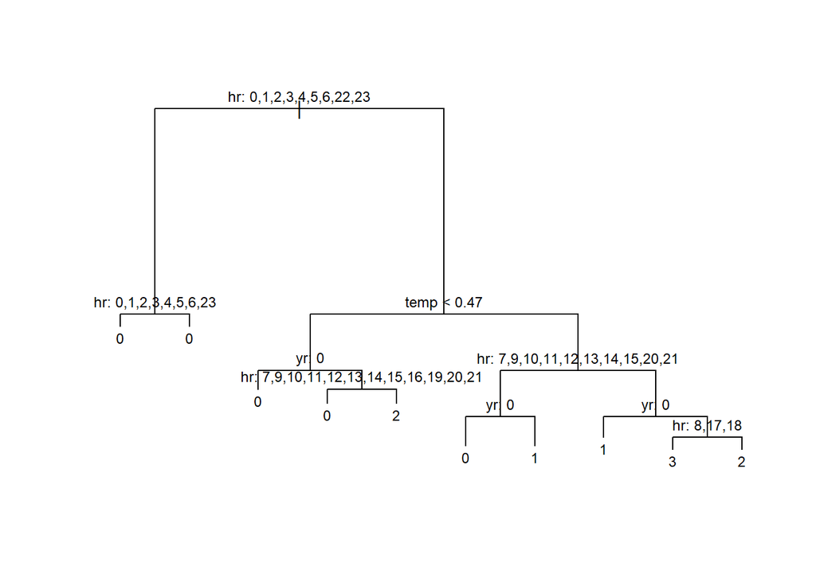

```r
plot(tree.classification.bike.1)
text(tree.classification.bike.1, pretty=1, cex=0.75)
```

As can be seen, the attribute hr is the root and therefore the most important attribute. As the summary has already shown, only hr, yr and temp are used for the classification. Furthermore, there are only 10 leaves or end nodes.

Now a prediction is to be made on the already known data, so that hits and error rate can be calculated afterwards.

```r
tree.classification.bike.pred.train <- predict(tree.classification.bike.1, d.bike.train.new, type="class")
(tree.classification.bike.pred.train.ct <- table(tree.classification.bike.pred.train, as.factor(d.bike.train.new$class)))
```

```
##
## tree.classification.bike.pred.train    0    1    2    3    4
##                                   0 7587 1684  227    5    0
##                                   1  279 1340  624  124    0
##                                   2  107  146  314  112    4
##                                   3   38   38   89  177  139
##                                   4    0    0    0    0    0
```

```r
tree.classification.bike.pred.train.correct <- 0
tree.classification.bike.pred.train.error <- 0
for (i1 in 1:3) {
  for (i2 in 1:3) {
    if (i1 == i2) {
      tree.classification.bike.pred.train.correct <- tree.classification.bike.pred.train.correct + tree.classification.bike.pred.train.ct[i1,i2]
    }else{
      tree.classification.bike.pred.train.error <- tree.classification.bike.pred.train.error + tree.classification.bike.pred.train.ct[i1,i2]
    }
  }
}
(tree.classification.bike.pred.train.rate <- tree.classification.bike.pred.train.correct/sum(tree.classification.bike.pred.train.ct))
```

```
## [1] 0.7089919
```

```r
(tree.classification.bike.pred.train.error <- 1 - tree.classification.bike.pred.train.rate)
```

```
## [1] 0.2910081
```

The table shows that the classification makes many errors. For example, data records are classified as 0 although they are not class 0. The hits and error rate confirms this. About 70% of the data objects are correctly classified and about 30% are incorrectly classified. What does the result now look like on the test data set?

```r
tree.classification.bike.pred.test <- predict(tree.classification.bike.1, d.bike.test.new, type="class")
(tree.classification.bike.pred.test.ct <- table(tree.classification.bike.pred.test, as.factor(d.bike.test.new$class)))
```

```
##
## tree.classification.bike.pred.test    0    1    2    3    4
##                                  0 2502  624   66    0    0
##                                  1   80  441  197   36    0
##                                  2   36   54  105   39    3
##                                  3   13   14   34   69   32
##                                  4    0    0    0    0    0
```

```r
tree.classification.bike.pred.test.correct <- 0
tree.classification.bike.pred.test.error <- 0
for (i1 in 1:3) {
  for (i2 in 1:3) {
    if (i1 == i2) {
      tree.classification.bike.pred.test.correct <- tree.classification.bike.pred.test.correct + tree.classification.bike.pred.test.ct[i1,i2]
    }else{
      tree.classification.bike.pred.test.error <- tree.classification.bike.pred.test.error + tree.classification.bike.pred.test.ct[i1,i2]
    }
  }
}
(tree.classification.bike.pred.test.rate <- tree.classification.bike.pred.test.correct/sum(tree.classification.bike.pred.test.ct))
```

```
## [1] 0.701496
```

```r
(tree.classification.bike.pred.test.error <- 1 - tree.classification.bike.pred.test.rate)
```

```
## [1] 0.298504
```

The result is basically the same. The test data set is also classified with a hit rate of 70% and an error rate of 30%. Pruning could possibly improve this result.

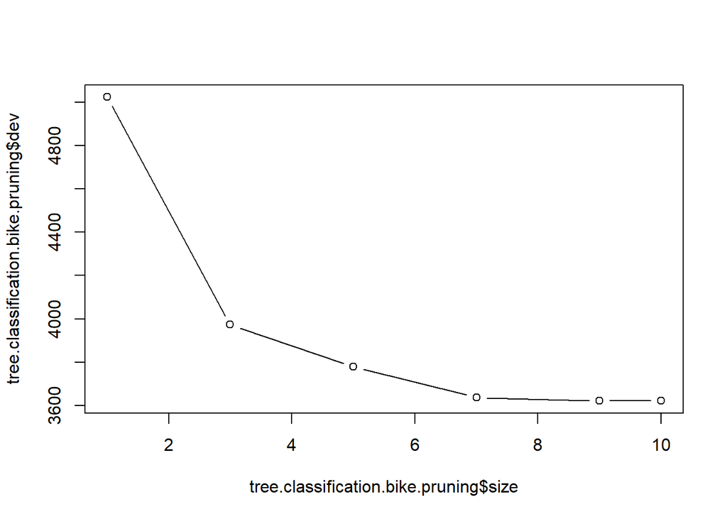

```r
tree.classification.bike.pruning <- cv.tree(tree.classification.bike.1, FUN = prune.misclass)
plot(tree.classification.bike.pruning$size, tree.classification.bike.pruning$dev, type="b")
```

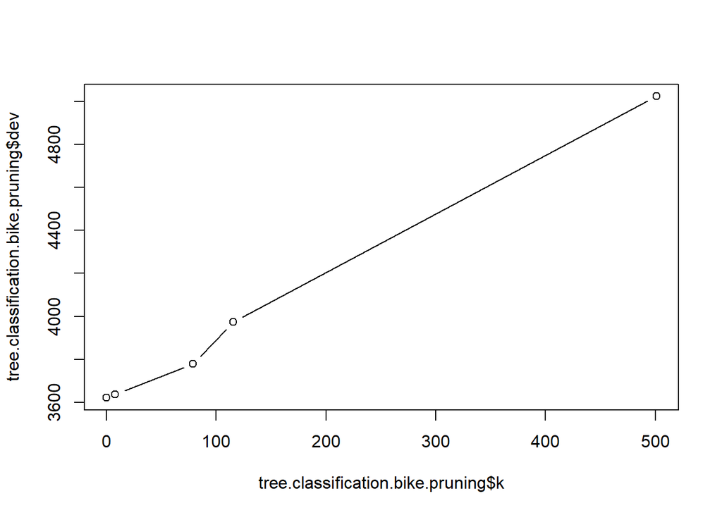

```r
plot(tree.classification.bike.pruning$k, tree.classification.bike.pruning$dev, type="b")
```

The graph shows that probably flattens from a size of 7. So for the parameter “best” 7 is chosen. Now the pruning can be performed.

```r
prune.tree.classification.bike <- prune.misclass(tree.classification.bike.1, best=7)
summary(prune.tree.classification.bike)
```

```
##
## Classification tree:
## snip.tree(tree = tree.classification.bike.1, nodes = c(2L, 6L
## ))
## Variables actually used in tree construction:
## [1] "hr"   "temp" "yr"
## Number of terminal nodes:  7
## Residual mean deviance:  1.333 = 17360 / 13030
## Misclassification error rate: 0.2787 = 3632 / 13034
```

This procedure enabled the tree to be pruned by three leaves. What does the pruned tree look like visually?

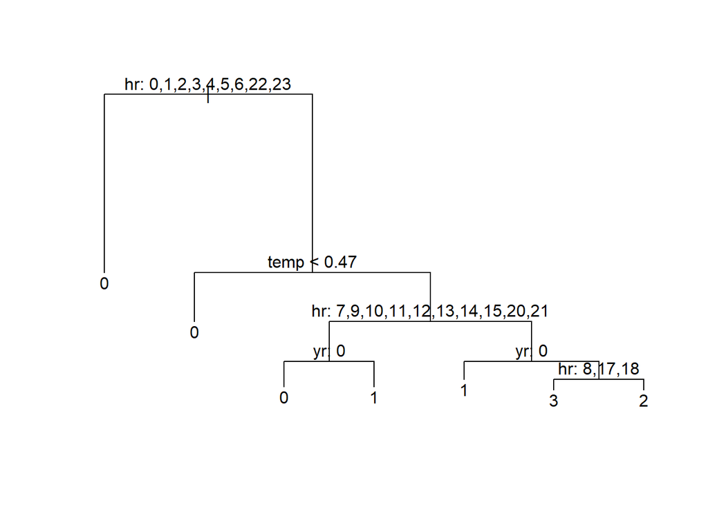

```r
plot(prune.tree.classification.bike)
text(prune.tree.classification.bike,pretty=0)
```

hr is still the most important attribute and therefore the root of the tree. The left branch of the initial tree now disappears completely. The right branches could also be reduced. Now the performance prediction on the test data set is to be checked, so that a comparison with the initial tree can be made.

```r
prune.tree.classification.bike.pred.test <- predict(prune.tree.classification.bike,  d.bike.test.new, type="class")
(prune.tree.classification.bike.pred.test.ct <- table(prune.tree.classification.bike.pred.test, as.factor(d.bike.test.new$class)))
```

```
##
## prune.tree.classification.bike.pred.test    0    1    2    3    4
##                                        0 2536  645  101   21    3
##                                        1   80  441  197   36    0
##                                        2    2   33   70   18    0
##                                        3   13   14   34   69   32
##                                        4    0    0    0    0    0
```

```r
(prune.tree.classification.bike.pred.test.correct <- sum(prune.tree.classification.bike.pred.test==as.factor(d.bike.test.new$class))/sum(prune.tree.classification.bike.pred.test.ct))
```

```
## [1] 0.7171461
```

```r
(prune.tree.classification.bike.pred.test.error <- 1 - prune.tree.classification.bike.pred.test.correct)
```

```
## [1] 0.2828539
```

```r
tree.classification.bike.pred.test.rate
```

```
## [1] 0.701496
```

```r
tree.classification.bike.pred.test.error
```

```
## [1] 0.298504
```

The table as well as the error and hit rates show that even the trimmed tree still makes errors in the classification. The improvement is - as can be seen from the lower two values - minimal.

## Regression Tree

Count values are not bell-shaped distributed

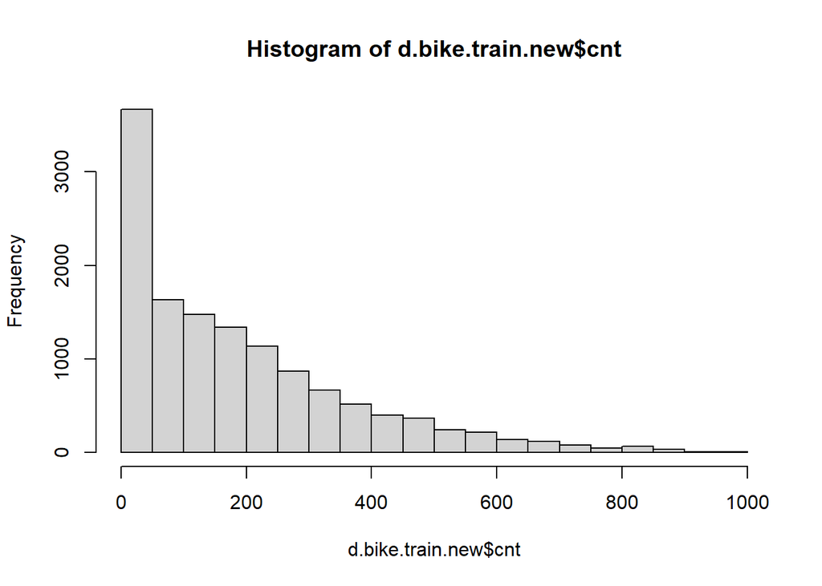

```r
hist(d.bike.train.new$cnt)
```

in this section the variable “cnt” will be predicted (–> factor)

```r
table(d.bike.train.new$cnt)
```

```
##
##   1   2   3   4   5   6   7   8   9  10  11  12  13  14  15  16  17  18  19  20
## 105 151 168 167 205 179 149 142  93 122 106  88  93  76  64  82  82  62  50  68
##  21  22  23  24  25  26  27  28  29  30  31  32  33  34  35  36  37  38  39  40
##  72  51  61  58  52  72  55  59  44  45  55  54  45  47  49  48  41  39  43  47
##  41  42  43  44  45  46  47  48  49  50  51  52  53  54  55  56  57  58  59  60
##  41  44  35  38  38  37  40  30  28  45  35  39  33  34  36  34  35  25  36  31
##  61  62  63  64  65  66  67  68  69  70  71  72  73  74  75  76  77  78  79  80
##  27  41  32  51  30  28  24  32  42  33  39  37  26  25  40  28  24  43  39  26
##  81  82  83  84  85  86  87  88  89  90  91  92  93  94  95  96  97  98  99 100
##  25  22  29  40  25  41  34  32  30  46  33  35  33  30  37  32  27  28  30  19
## 101 102 103 104 105 106 107 108 109 110 111 112 113 114 115 116 117 118 119 120
##  24  33  28  31  30  37  27  41  27  29  24  32  33  40  23  34  28  39  30  26
## 121 122 123 124 125 126 127 128 129 130 131 132 133 134 135 136 137 138 139 140
##  31  31  41  34  29  32  30  22  36  28  22  18  30  29  37  29  27  28  26  30
```

[output cut: 70 more lines]

“cnt” is a categorical variable -> normally classification tree is to be used. but since it has more than 32 levels, regression tree is to be generated.

```r
#tree.classification.bike <- tree(as.factor(cnt) ~ .-class, data = d.bike.train.new)
#tree.classification.bike.pred <- predict(tree.classification.bike, d.bike.train.new, type="class")
```

regression tree is generated:

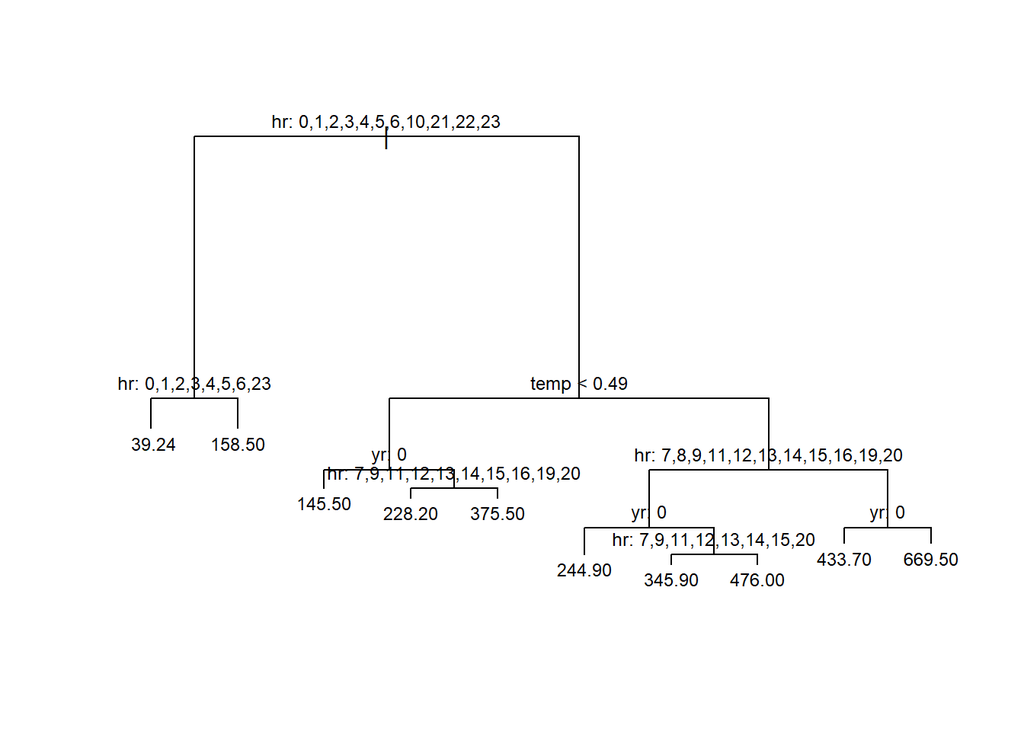

```r
tree.regression.bike <- tree(cnt ~ .-class, data = d.bike.train.new)
plot(tree.regression.bike)
text(tree.regression.bike, pretty=1, cex=0.75)
```

tree has 10 nodes. See summary:

```r
summary(tree.regression.bike)
```

```
##
## Regression tree:
## tree(formula = cnt ~ . - class, data = d.bike.train.new)
## Variables actually used in tree construction:
## [1] "hr"   "temp" "yr"
## Number of terminal nodes:  10
## Residual mean deviance:  11230 = 146300000 / 13020
## Distribution of residuals:
##    Min. 1st Qu.  Median    Mean 3rd Qu.    Max.
## -554.50  -50.47  -17.24    0.00   53.76  514.80
```

….regression tree is used for prediction. prediction is made based on training data

```r
tree.regression.bike.train.pred <- predict(tree.regression.bike, d.bike.train.new, type="vector")
```

predictions of regression tree with true “cnt” values are compared. it shows a positive correlation see graphic:

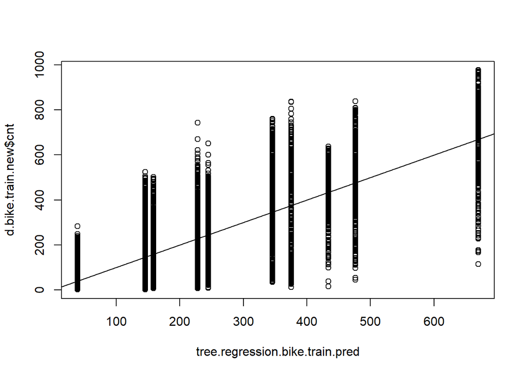

```r
plot(tree.regression.bike.train.pred,d.bike.train.new$cnt)
abline (0 ,1) # compare with the function f(x)=x (intercept 0, slope 1)
```

errors are calculated (error residual calculation: [predicted “cnt” values] - [real “cnt” values])

```r
error <- tree.regression.bike.train.pred-d.bike.train.new$cnt
element_ID <- 1:length(error)
```

Analysis of the resuduals: The majority of the residents are within the frequency of 200 see graphic:

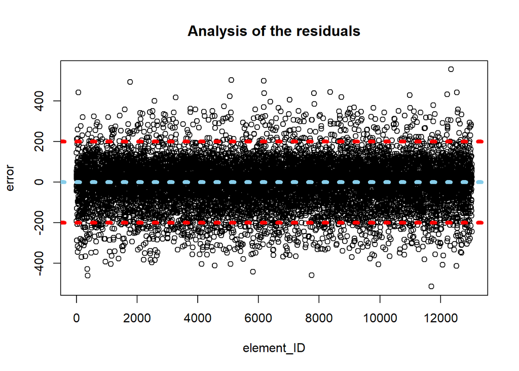

```r
plot(element_ID,error)
title(main="Analysis of the residuals")
abline(0 ,0, lwd=5, col="skyblue", lty="dotted")
abline(200 ,0, lwd=5, col="red", lty="dotted")
abline(-200 ,0, lwd=5, col="red", lty="dotted")
```

Histogram of error: Most errors do not seem to be over 200 up and down (as already seen in the residence analysis above). The errors appear to be bell shaped. see graphic:

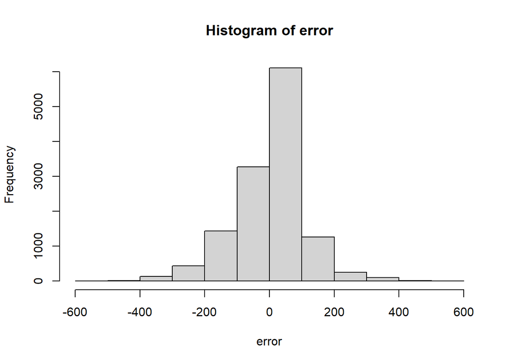

```r
hist(error)
```

some numbers on train data RSS: 146263805 MSE: 11221.71 deviation: 105.9326 …calculated with following code:

```r
(RSS <- sum((d.bike.train.new["cnt"]-tree.regression.bike.train.pred)^2))
```

```
## [1] 146263805
```

```r
(MSE <- mean(((d.bike.train.new["cnt"]-tree.regression.bike.train.pred)^2)$cnt))
```

```
## [1] 11221.71
```

```r
(deviation <- sqrt(MSE))
```

```
## [1] 105.9326
```

a prediction is made based on test data

```r
tree.regression.bike.test.pred <- predict(tree.regression.bike, d.bike.test.new, type="vector")
```

MSE: An MSE comparison is made between train and test data. Both MSE-values are very close to each other and this shows a very good performance of the tree. MSE of training data: 11221.71 MSE of test data: 10638.24

```r
(MSE.train <- mean(((d.bike.train.new["cnt"]-tree.regression.bike.train.pred)^2)$cnt))
```

```
## [1] 11221.71
```

```r
(MSE.test <- mean(((d.bike.test.new["cnt"]-tree.regression.bike.test.pred)^2)$cnt))
```

```
## [1] 10638.24
```

Graphical comparison of error residuals between training and test data: result: As one can see in the graph, the distribution of error rates between training and test data looks the same –> good performance of the decision tree! see graphic:

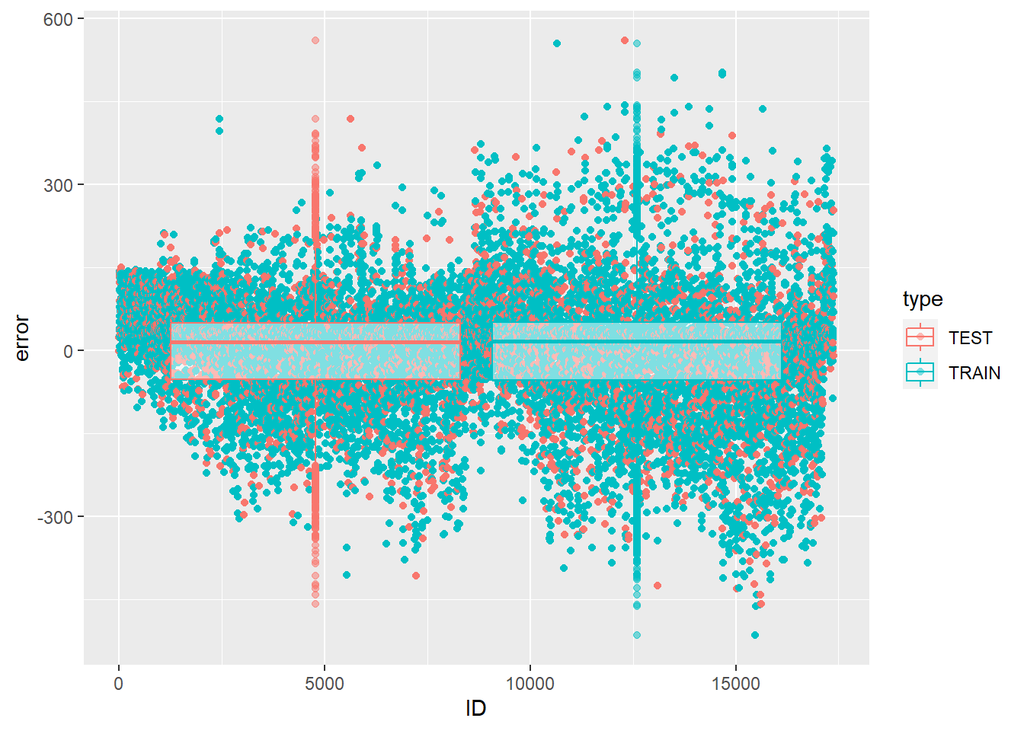

```r
errors.2.in <- predict(tree.regression.bike, d.bike.train.new, type="vector")-d.bike.train.new$cnt
element.2.in <- as.integer(names(errors.2.in))
errors.2.in_dataframe <- tibble(element.2.in,errors.2.in,"TRAIN")
colnames(errors.2.in_dataframe) <- c('ID','error','type')
errors.2 <- predict(tree.regression.bike, d.bike.test.new, type="vector")-d.bike.test.new$cnt
element.2 <- as.integer(names(errors.2))
errors.2.out_dataframe <- tibble(element.2,errors.2,"TEST")
colnames(errors.2.out_dataframe) <- c('ID','error','type')

errors.2_dataframe <- bind_rows(errors.2.in_dataframe,errors.2.out_dataframe)
errors.2_dataframe <- arrange(errors.2_dataframe, ID)

ggplot(data = errors.2_dataframe, mapping = aes(x = ID,y = error, color = type)) +
  geom_point() + geom_boxplot(alpha = 0.5)
```

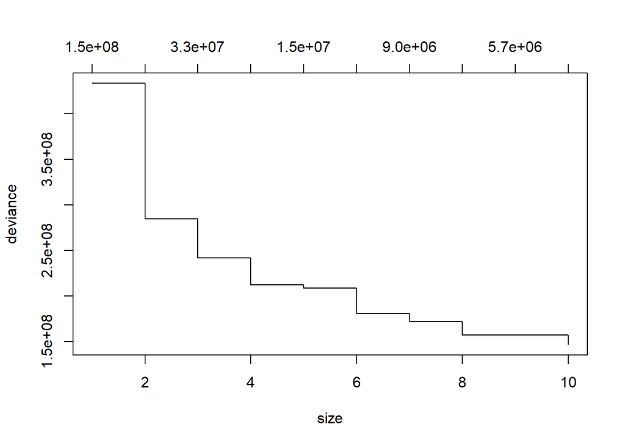

```r
tree.regression.bike.pruning = cv.tree(tree.regression.bike, FUN = prune.tree)
plot(tree.regression.bike.pruning)
```

cross-validation error-rate based on size and k:

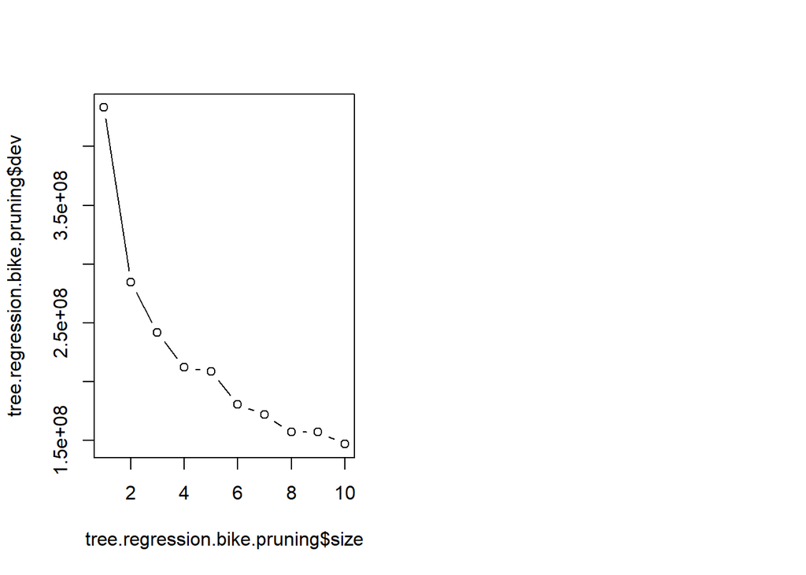

```r
par(mfrow=c(1,2))
plot(tree.regression.bike.pruning$size, tree.regression.bike.pruning$dev, type="b")
```

On this graphic, one can see that after 5.0e+0.7 k, the curve flattens out:

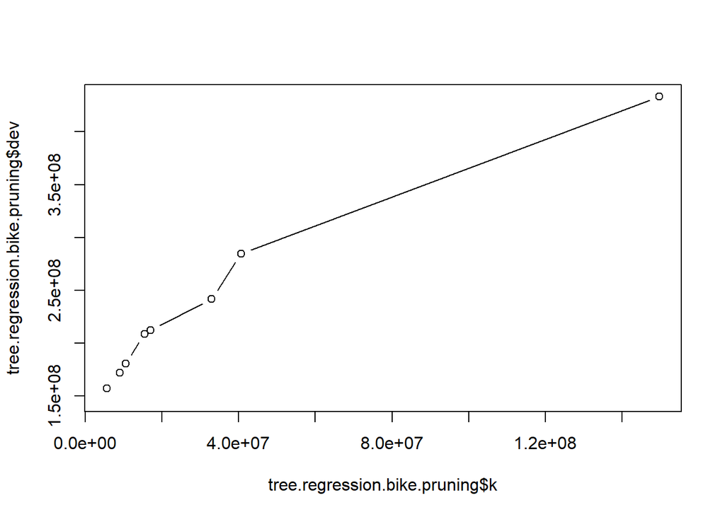

```r
plot(tree.regression.bike.pruning$k, tree.regression.bike.pruning$dev, type="b")
```

```r
par(mfrow=c(1,1))
```

–> On this level the number of leaves should be chosen.

Based on the findings above, the tree was created once with 4 and once with 5 nodes. With the tree with 5 nodes, the goal was to find out whether the expected lower mean deviance would allow a better tree. Result: Both trees (generated below) are good, none of them has unnecessary decisions. see graphics of both trees:

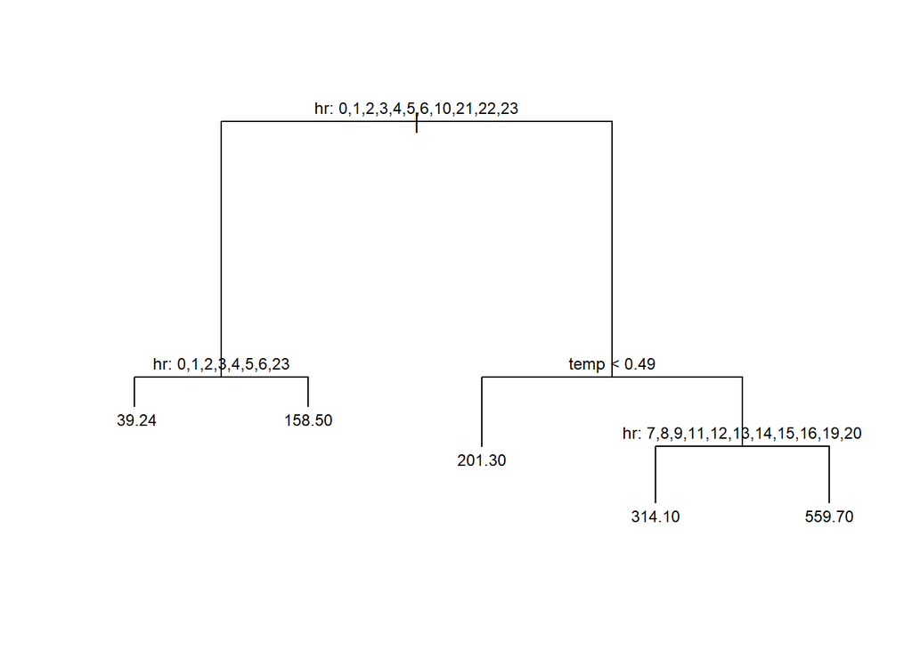

```r
tree.regression.bike.pruned <- prune.tree(tree.regression.bike, best = 5)
plot(tree.regression.bike.pruned)
text(tree.regression.bike.pruned, pretty=1, cex=0.75)
```

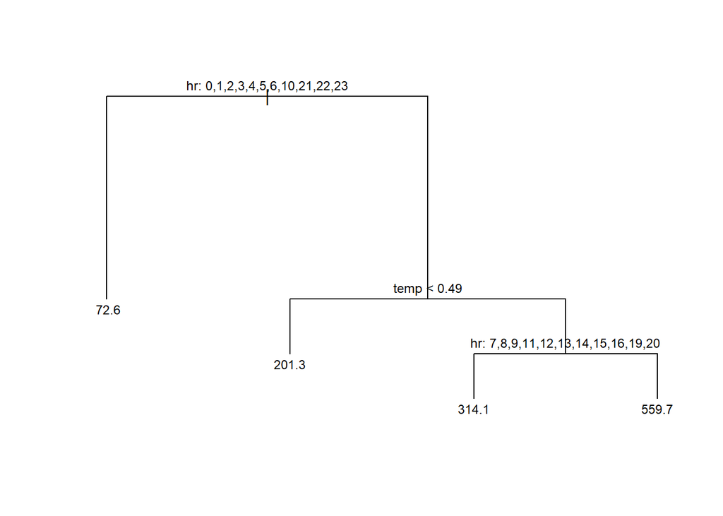

```r
tree.regression.bike.pruned2 <- prune.tree(tree.regression.bike, best = 4)
plot(tree.regression.bike.pruned2)
text(tree.regression.bike.pruned2, pretty=1, cex=0.75)
```

Summary of both trees: mean deviance of tree with 5 leaves (“tree.regression.bike.pruned”): 14790 mean deviance of tree with 4 leaves (“tree.regression.bike.pruned2”): 16100 For the further part of the residual tree analysis (only within this section), the tree with five nodes is to be preferred, since it has a lower mean deviance. sidenote: in the summary of the trees, one can also see that only the dimensions “hr” and “temp” are used in both trees after the prune. summary of tree with 5 leaves:

```r
summary(tree.regression.bike.pruned)
```

```
##
## Regression tree:
## snip.tree(tree = tree.regression.bike, nodes = c(15L, 6L, 14L
## ))
## Variables actually used in tree construction:
## [1] "hr"   "temp"
## Number of terminal nodes:  5
## Residual mean deviance:  14790 = 192700000 / 13030
## Distribution of residuals:
##    Min. 1st Qu.  Median    Mean 3rd Qu.    Max.
## -544.70  -64.02  -20.24    0.00   50.76  635.70
```

summary of tree with 4 leaves:

```r
summary(tree.regression.bike.pruned2)
```

```
##
## Regression tree:
## snip.tree(tree = tree.regression.bike, nodes = c(15L, 6L, 14L,
## 2L))
## Variables actually used in tree construction:
## [1] "hr"   "temp"
## Number of terminal nodes:  4
## Residual mean deviance:  16100 = 209800000 / 13030
## Distribution of residuals:
##    Min. 1st Qu.  Median    Mean 3rd Qu.    Max.
## -544.70  -68.60  -31.12    0.00   60.37  635.70
```

Next was about prediction tests on the recently pruned tree with five nodes. Result: With train data we came to an MSE of 14785.88 and with test data to 14245.44. –> These two values are very close to each other and this shows a very good performance of the tree.

Prediction using pruned tree based on training data:

```r
tree.regression.bike.pruned.train.pred <- predict(tree.regression.bike.pruned, d.bike.train.new, type="vector")
(MSE.pruned.train <- mean(((d.bike.train.new["cnt"]-tree.regression.bike.pruned.train.pred)^2)$cnt))
```

```
## [1] 14785.88
```

Prediction using pruned tree based on test data:

```r
tree.regression.bike.pruned.test.pred <- predict(tree.regression.bike.pruned, d.bike.test.new, type="vector")
(MSE.pruned.test <- mean(((d.bike.test.new["cnt"]-tree.regression.bike.pruned.test.pred)^2)$cnt))
```

```
## [1] 14245.44
```